# Micronutrient Deficiency Prediction: Multi-Country Results Report

### 7.2.6 Iron deficiency (women)

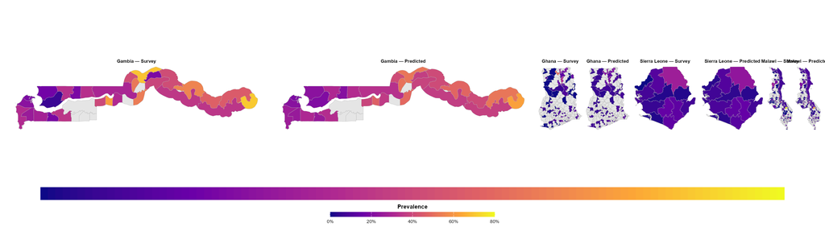

Admin-2 prevalence: Iron deficiency (women)

### 7.2.7 Vitamin A (women)

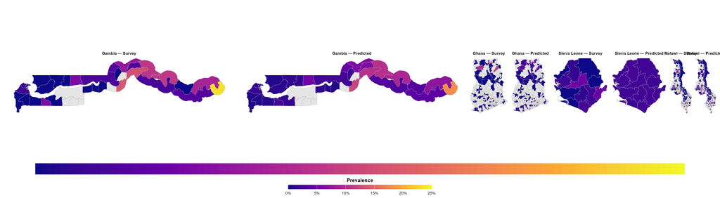

Admin-2 prevalence: Vitamin A (women)

### 7.2.8 Zinc deficiency (women)

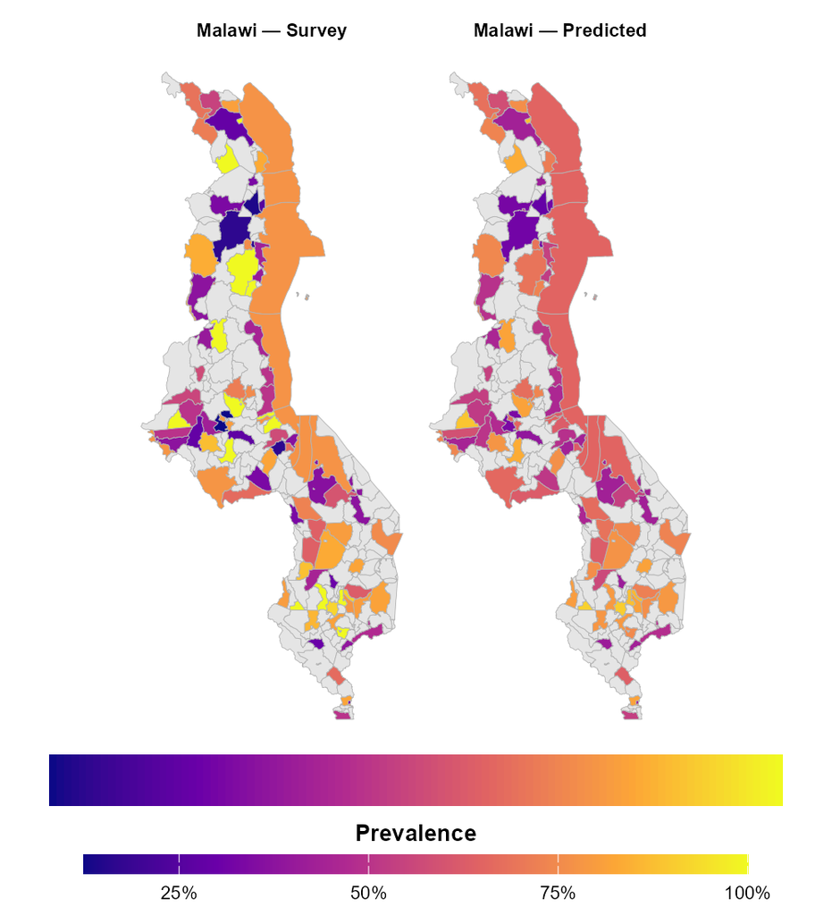

Admin-2 prevalence: Zinc deficiency (women)

Admin-2 districts with very few survey respondents (< 15) may have unreliable observed prevalences. SL predictions smooth over sampling noise by aggregating individual-level model predictions.

## 7.3 Malawi Admin-2: Extrapolation to Unsurveyed Districts

Not all Malawi Admin-2 districts have sufficient survey respondents for direct prevalence estimation. For unsurveyed districts, we fit an area-level elastic net model on surveyed districts (survey prevalence ~ GEE raster covariates) and extrapolate to all districts. Uncertainty is quantified via LOO conformal prediction intervals.

Maps are pre-rendered by `scripts/malawi_admin2_oos.R`. Each 4-panel figure shows: (1) observed survey prevalence (unsurveyed = grey), (2) SL-predicted prevalence (surveyed only), (3) extrapolated predictions for all districts (unsurveyed outlined in red dashes), (4) conformal prediction interval width.

```r
mw_pngs <- list.files(here("results", "figures"),
                       pattern = "^malawi_oos_admin2_.*\\.png$", full.names = TRUE)
if (length(mw_pngs) > 0) {
  for (f in sort(mw_pngs)) {
    oc_tag <- sub("malawi_oos_admin2_(.*)\\.png", "\\1", basename(f))
    oc_label <- outcome_labels[oc_tag]
    if (is.na(oc_label)) oc_label <- oc_tag
    cat(sprintf("\n\n### %s\n\n", oc_label))
    cat(sprintf("![Malawi OOS: %s](%s){width=100%%}\n\n", oc_label, f))
  }
} else {
  cat("Malawi OOS maps not found. Run `Rscript scripts/malawi_admin2_oos.R`.\n")
}
```

### 7.3.1 Iron deficiency (children)

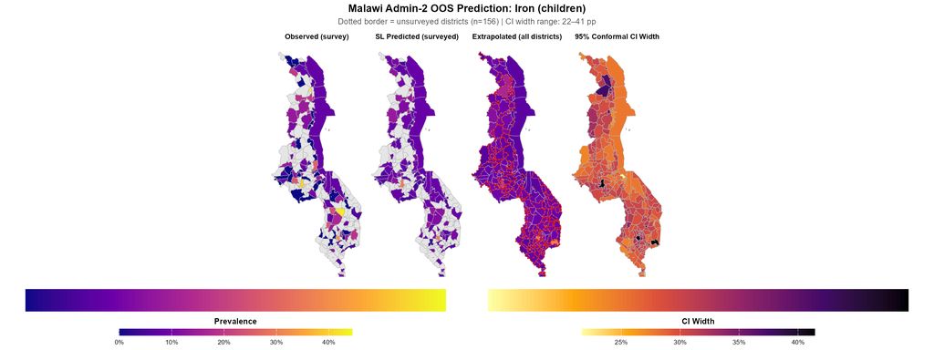

Malawi OOS: Iron deficiency (children)

### 7.3.2 Vitamin A (children)

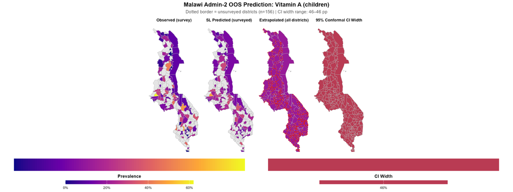

Malawi OOS: Vitamin A (children)

### 7.3.3 Zinc deficiency (children)

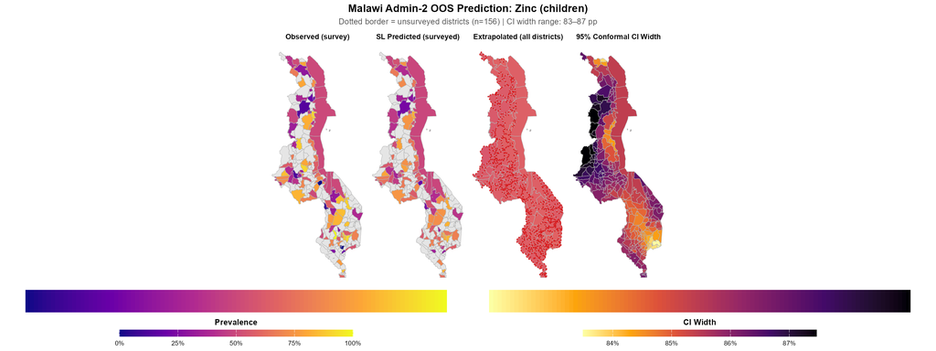

Malawi OOS: Zinc deficiency (children)

### 7.3.4 Vitamin B12 deficiency (women)

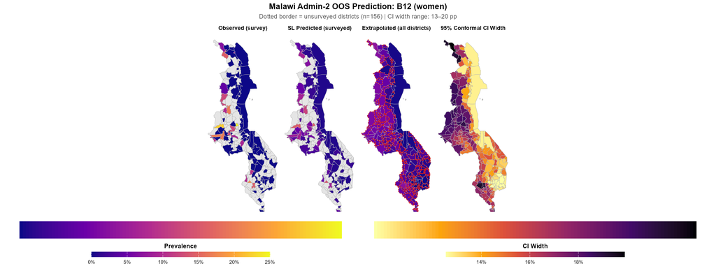

Malawi OOS: Vitamin B12 deficiency (women)

### 7.3.5 Iron deficiency (women)

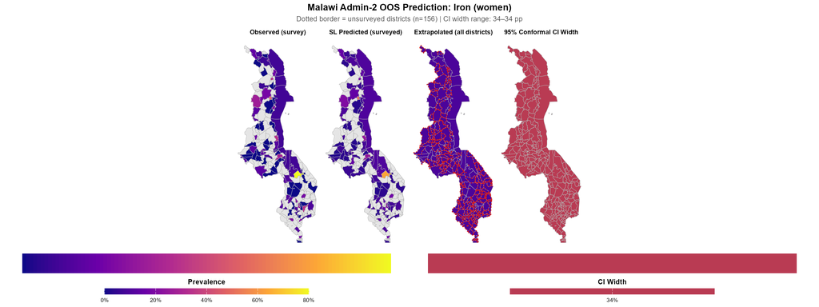

Malawi OOS: Iron deficiency (women)

### 7.3.6 Vitamin A (women)

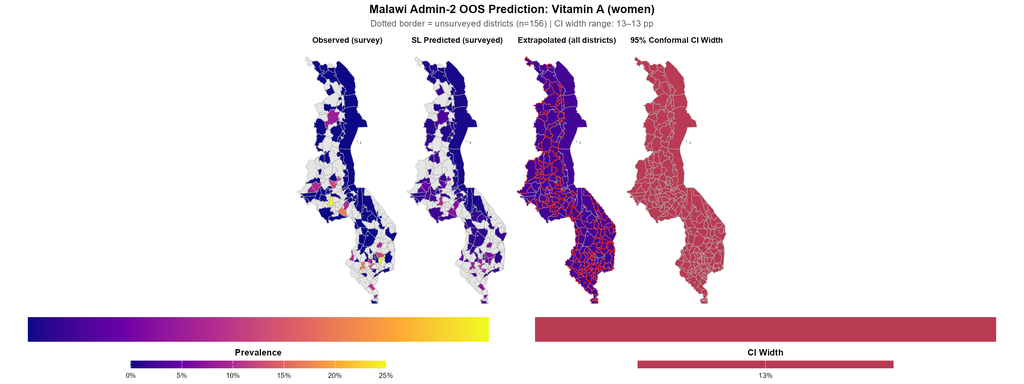

Malawi OOS: Vitamin A (women)

### 7.3.7 Zinc deficiency (women)

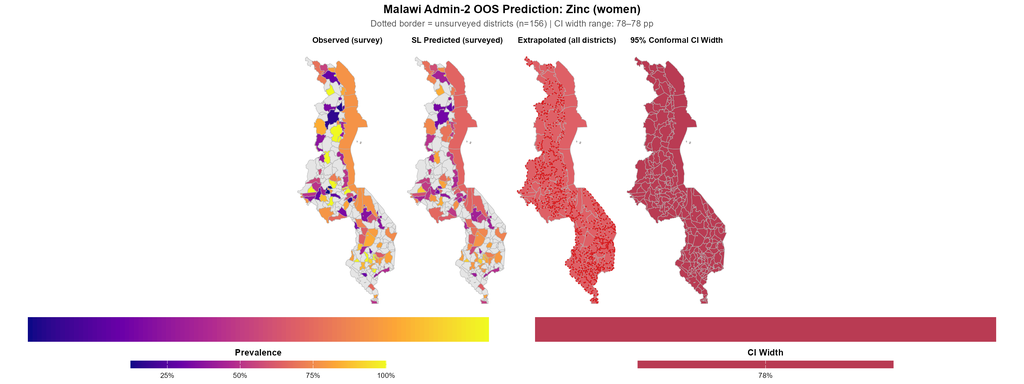

Malawi OOS: Zinc deficiency (women)

# 8 Comparative Analysis: Individual-Level vs. Area-Level Prediction

This section compares three approaches to predicting Admin-2 prevalence:

- **Individual SL**: SuperLearner trained on individual biomarker data, predictions aggregated to Admin-2
- **Area SL (MSE)**: SuperLearner trained directly on Admin-2 survey prevalence using MSE/continuous loss
- **Area SL (NLL)**: SuperLearner trained on Admin-2 prevalence using negative log-likelihood (binomial loss, inspired by beta regression theory) — naturally handles bounded [0,1] data

## 8.1 Within-Country Comparison

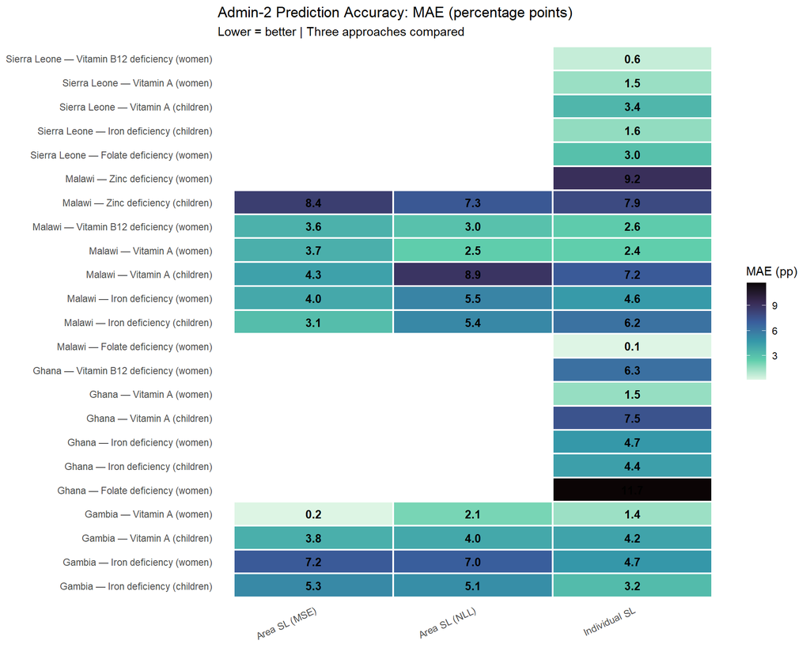

```r
area_comp <- load_target("area_comparison_all")
if (!is.null(area_comp) && nrow(area_comp) > 0) {
  comp_plot <- area_comp |>
    mutate(
      outcome_label = outcome_labels[outcome],
      ctry_outcome = paste0(country, " — ", outcome_label)
    )

  ggplot(comp_plot, aes(x = approach, y = ctry_outcome, fill = mae_pp)) +
    geom_tile(colour = "white", linewidth = 0.8) +
    geom_text(aes(label = sprintf("%.1f", mae_pp)), size = 3.5, fontface = "bold") +
    scale_fill_viridis_c(name = "MAE (pp)", option = "mako", direction = -1) +
    labs(x = NULL, y = NULL,
         title = "Admin-2 Prediction Accuracy: MAE (percentage points)",
         subtitle = "Lower = better | Three approaches compared") +
    theme_minimal(base_size = 11) +
    theme(axis.text.x = element_text(angle = 25, hjust = 1),
          panel.grid = element_blank())
} else {
  cat("Area comparison targets not yet available. Run the pipeline.\n")
}
```

```r
if (!is.null(area_comp) && nrow(area_comp) > 0) {
  comp_display <- area_comp |>
    mutate(outcome_label = outcome_labels[outcome]) |>
    select(Country = country, Outcome = outcome_label, Approach = approach,
           `N Admin-2` = n_admin2, `MAE (pp)` = mae_pp, `RMSE (pp)` = rmse_pp,
           `Pearson r` = pearson_r, `Bias (pp)` = mean_bias_pp)

  kable(comp_display,
        caption = "Within-country Admin-2 prediction accuracy: three approaches") |>
    kable_styling(bootstrap_options = c("striped", "hover"),
                  full_width = FALSE, font_size = 10) |>
    collapse_rows(columns = 1:2, valign = "top")
}
```

Within-country Admin-2 prediction accuracy: three approaches

| Country | Outcome | Approach | N Admin-2 | MAE (pp) | RMSE (pp) | Pearson r | Bias (pp) |
| --- | --- | --- | --- | --- | --- | --- | --- |
| Gambia | Vitamin A (children) | Individual SL | 30 | 4.24 | 5.79 | 0.914 | 0.66 |
|  |  | Area SL (MSE) | 30 | 3.75 | 4.90 | 0.963 | -0.13 |
|  |  | Area SL (NLL) | 30 | 4.04 | 5.44 | 0.935 | -2.35 |
|  | Vitamin A (women) | Individual SL | 30 | 1.43 | 1.85 | 0.970 | 0.06 |
|  |  | Area SL (MSE) | 30 | 0.16 | 0.21 | 1.000 | 0.01 |
|  |  | Area SL (NLL) | 30 | 2.07 | 3.78 | 0.923 | -1.79 |
|  | Iron deficiency (children) | Individual SL | 30 | 3.24 | 4.70 | 0.974 | 0.07 |
|  |  | Area SL (MSE) | 30 | 5.33 | 6.85 | 0.962 | 0.06 |
|  |  | Area SL (NLL) | 30 | 5.10 | 6.54 | 0.955 | -0.76 |
|  | Iron deficiency (women) | Individual SL | 30 | 4.74 | 6.89 | 0.921 | -0.18 |
|  |  | Area SL (MSE) | 30 | 7.19 | 9.39 | 0.812 | 0.00 |
|  |  | Area SL (NLL) | 30 | 7.03 | 9.22 | 0.818 | -0.83 |
| Ghana | Vitamin A (children) | Individual SL | 75 | 7.53 | 9.86 | 0.728 | 0.99 |
|  | Vitamin A (women) | Individual SL | 75 | 1.54 | 2.38 | 0.833 | 0.19 |
|  | Iron deficiency (children) | Individual SL | 75 | 4.40 | 6.72 | 0.930 | 0.42 |
|  | Iron deficiency (women) | Individual SL | 75 | 4.73 | 6.23 | 0.814 | 1.26 |
|  | Folate deficiency (women) | Individual SL | 75 | 11.69 | 14.89 | 0.903 | -0.25 |
|  | Vitamin B12 deficiency (women) | Individual SL | 75 | 6.30 | 9.43 | 0.875 | -0.23 |
| Sierra Leone | Vitamin A (children) | Individual SL | 14 | 3.43 | 4.26 | 0.839 | 0.38 |
|  | Vitamin A (women) | Individual SL | 14 | 1.47 | 1.73 | 0.667 | 0.70 |
|  | Iron deficiency (children) | Individual SL | 14 | 1.62 | 2.13 | 0.895 | 0.25 |
|  | Folate deficiency (women) | Individual SL | 14 | 3.04 | 3.91 | 0.939 | -0.91 |
|  | Vitamin B12 deficiency (women) | Individual SL | 14 | 0.64 | 0.69 | -0.312 | 0.10 |
| Malawi | Vitamin A (children) | Individual SL | 87 | 7.20 | 9.42 | 0.735 | -0.07 |
|  |  | Area SL (MSE) | 87 | 4.35 | 5.51 | 0.971 | 0.31 |
|  |  | Area SL (NLL) | 87 | 8.91 | 12.49 | 0.492 | -4.78 |
|  | Vitamin A (women) | Individual SL | 87 | 2.45 | 3.81 | 0.847 | -0.03 |
|  |  | Area SL (MSE) | 87 | 3.72 | 5.24 | 0.440 | 0.00 |
|  |  | Area SL (NLL) | 87 | 2.50 | 5.77 | 0.643 | -2.10 |
|  | Iron deficiency (children) | Individual SL | 87 | 6.21 | 8.00 | 0.735 | -0.25 |
|  |  | Area SL (MSE) | 87 | 3.14 | 4.16 | 0.976 | -0.02 |
|  |  | Area SL (NLL) | 87 | 5.36 | 8.46 | 0.897 | -5.08 |
|  | Iron deficiency (women) | Individual SL | 87 | 4.63 | 6.07 | 0.897 | 0.27 |
|  |  | Area SL (MSE) | 87 | 4.03 | 5.90 | 0.957 | 0.31 |
|  |  | Area SL (NLL) | 87 | 5.51 | 10.16 | 0.922 | -5.21 |
|  | Folate deficiency (women) | Individual SL | 87 | 0.14 | 1.34 | NA | -0.14 |
|  | Vitamin B12 deficiency (women) | Individual SL | 87 | 2.57 | 3.38 | 0.893 | 0.25 |
|  |  | Area SL (MSE) | 87 | 3.63 | 5.07 | 0.578 | 0.02 |
|  |  | Area SL (NLL) | 87 | 2.97 | 6.22 | 0.633 | -2.51 |
|  | Zinc deficiency (children) | Individual SL | 87 | 7.91 | 10.58 | 0.937 | 0.25 |
|  |  | Area SL (MSE) | 87 | 8.44 | 10.35 | 0.975 | -0.24 |
|  |  | Area SL (NLL) | 87 | 7.30 | 9.04 | 0.943 | 0.70 |
|  | Zinc deficiency (women) | Individual SL | 87 | 9.17 | 11.76 | 0.938 | -1.28 |

## 8.2 Area-Level LOCO: Cross-Country Transportability

```r
area_loco <- load_target("area_loco_comparison")
if (!is.null(area_loco) && nrow(area_loco) > 0) {
  loco_display <- area_loco |>
    mutate(
      outcome_label = outcome_labels[outcome],
      loss = ifelse(model_type == "continuous", "MSE", "NLL")
    ) |>
    select(`Held out` = held_out, Outcome = outcome_label, Loss = loss,
           `N train` = n_train, `N test` = n_test,
           `Obs (%)` = obs_prev, `Pred (%)` = pred_prev,
           `MAE (pp)` = mae_pp, `r` = pearson_r) |>
    mutate(
      `Obs (%)` = round(`Obs (%)` * 100, 1),
      `Pred (%)` = round(`Pred (%)` * 100, 1)
    )

  kable(loco_display,
        caption = "Area-level LOCO: trained on 3 countries' Admin-2 data, tested on held-out") |>
    kable_styling(bootstrap_options = c("striped", "hover"),
                  full_width = FALSE, font_size = 10) |>
    collapse_rows(columns = 1:2, valign = "top")
} else {
  cat("Area-level LOCO targets not yet available.\n")
}
```

Area-level LOCO: trained on 3 countries' Admin-2 data, tested on held-out

| Held out | Outcome | Loss | N train | N test | Obs (%) | Pred (%) | MAE (pp) | r |
| --- | --- | --- | --- | --- | --- | --- | --- | --- |
| Gambia | Vitamin A (children) | MSE | 176 | 30 | 24.2 | 18.7 | 10.60 | 0.362 |
|  |  | NLL | 176 | 30 | 24.2 | 9.3 | 16.35 | 0.258 |
| Ghana |  | MSE | 131 | 75 | 18.7 | 19.9 | 11.03 | 0.447 |
|  |  | NLL | 131 | 75 | 18.7 | 21.4 | 12.78 | 0.015 |
| SierraLeone |  | MSE | 192 | 14 | 17.9 | 17.7 | 6.82 | -0.090 |
|  |  | NLL | 192 | 14 | 17.9 | 7.3 | 11.41 | -0.114 |
| Malawi |  | MSE | 119 | 87 | 20.0 | 28.9 | 13.49 | 0.203 |
|  |  | NLL | 119 | 87 | 20.0 | 31.7 | 17.05 | 0.159 |
| Gambia | Vitamin A (women) | MSE | 176 | 30 | 4.0 | 1.6 | 3.91 | -0.043 |
|  |  | NLL | 176 | 30 | 4.0 | 0.2 | 4.00 | 0.032 |
| Ghana |  | MSE | 131 | 75 | 1.2 | 2.7 | 3.23 | NA |
|  |  | NLL | 131 | 75 | 1.2 | 0.7 | 1.73 | 0.002 |
| SierraLeone |  | MSE | 192 | 14 | 1.6 | 2.2 | 1.49 | NA |
|  |  | NLL | 192 | 14 | 1.6 | 0.2 | 1.52 | 0.135 |
| Malawi |  | MSE | 119 | 87 | 2.4 | 3.6 | 4.70 | 0.073 |
|  |  | NLL | 119 | 87 | 2.4 | 0.6 | 2.78 | 0.052 |
| Gambia | Iron deficiency (children) | MSE | 176 | 30 | 42.5 | 16.0 | 27.06 | 0.175 |
|  |  | NLL | 176 | 30 | 42.5 | 5.8 | 36.79 | 0.148 |
| Ghana |  | MSE | 131 | 75 | 15.8 | 16.5 | 13.97 | 0.140 |
|  |  | NLL | 131 | 75 | 15.8 | 6.5 | 14.07 | -0.082 |
| SierraLeone |  | MSE | 192 | 14 | 5.9 | 13.8 | 8.10 | 0.029 |
|  |  | NLL | 192 | 14 | 5.9 | 3.6 | 4.83 | -0.103 |
| Malawi |  | MSE | 119 | 87 | 10.3 | 38.8 | 29.85 | -0.097 |
|  |  | NLL | 119 | 87 | 10.3 | 27.0 | 19.55 | -0.101 |
| Gambia | Iron deficiency (women) | MSE | 176 | 30 | 35.9 | 8.4 | 27.64 | -0.500 |
|  |  | NLL | 176 | 30 | 35.9 | 1.7 | 34.19 | -0.217 |
| Ghana |  | MSE | 131 | 75 | 7.9 | 16.2 | 10.98 | -0.003 |
|  |  | NLL | 131 | 75 | 7.9 | 8.2 | 7.42 | -0.023 |
| SierraLeone |  | MSE | 192 | 14 | 9.0 | 8.7 | 5.05 | -0.114 |
|  |  | NLL | 192 | 14 | 9.0 | 1.6 | 7.75 | -0.179 |
| Malawi |  | MSE | 119 | 87 | 9.2 | 20.9 | 15.62 | 0.001 |
|  |  | NLL | 119 | 87 | 9.2 | 13.0 | 10.65 | 0.055 |

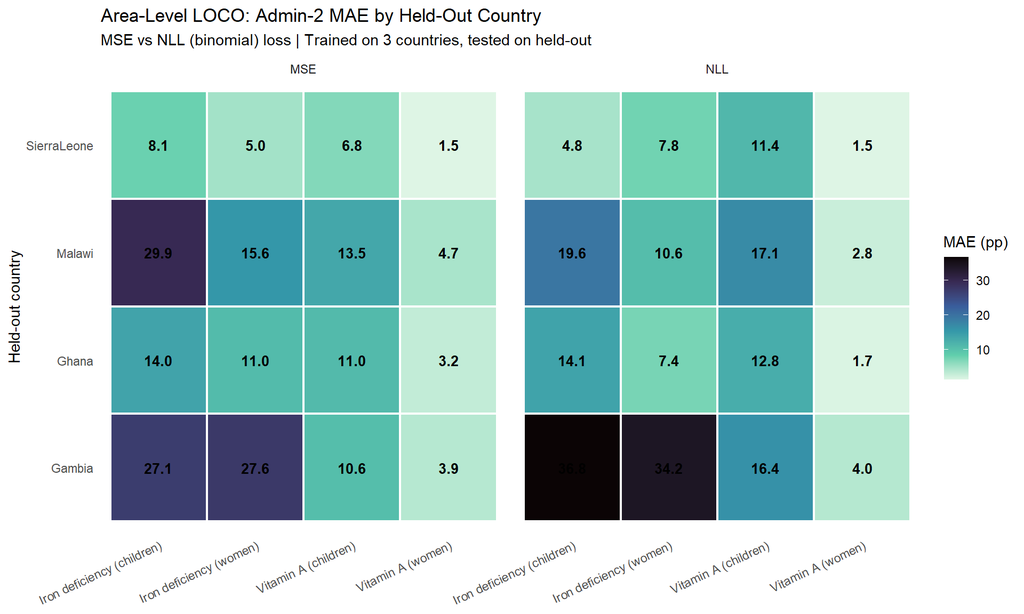

```r
if (!is.null(area_loco) && nrow(area_loco) > 0) {
  loco_plot <- area_loco |>
    mutate(
      outcome_label = outcome_labels[outcome],
      loss_label = ifelse(model_type == "continuous", "MSE", "NLL"),
      panel = paste0(outcome_label, " (", loss_label, ")")
    )

  ggplot(loco_plot, aes(x = outcome_label, y = held_out, fill = mae_pp)) +
    geom_tile(colour = "white", linewidth = 0.8) +
    geom_text(aes(label = sprintf("%.1f", mae_pp)), size = 3.5, fontface = "bold") +
    scale_fill_viridis_c(name = "MAE (pp)", option = "mako", direction = -1) +
    facet_wrap(~ loss_label) +
    labs(x = NULL, y = "Held-out country",
         title = "Area-Level LOCO: Admin-2 MAE by Held-Out Country",
         subtitle = "MSE vs NLL (binomial) loss | Trained on 3 countries, tested on held-out") +
    theme_minimal(base_size = 11) +
    theme(axis.text.x = element_text(angle = 25, hjust = 1),
          panel.grid = element_blank())
}
```

# 9 Continuous Outcome: Observed vs. Predicted Scatter

This section plots individual-level observed biomarker values (Y) against cross-validated predicted values (yhat_full) from the continuous SuperLearner fit, with a 45-degree reference line and Pearson correlation annotation.

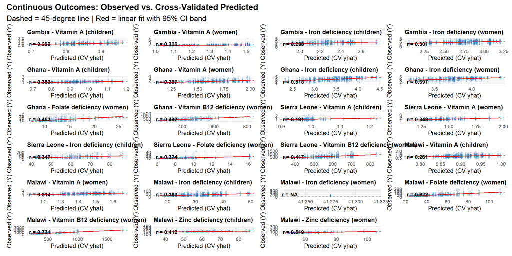

```r
scatter_panels <- list()

for (ctry in countries) {
  for (oc in outcomes) {
    suffix <- paste0(ctry, "_", oc)
    tname <- paste0("sl_fit_", suffix)
    sl_fit <- load_target(tname)
    if (is.null(sl_fit)) next

    cont_fit <- sl_fit$cont_fit
    if (is.null(cont_fit) || is.null(cont_fit$res)) next

    res <- cont_fit$res
    if (!all(c("Y", "yhat_full") %in% colnames(res))) next
    if (nrow(res) == 0) next

    d_scatter <- data.frame(
      Y = as.numeric(res$Y),
      yhat = as.numeric(res$yhat_full)
    ) |> filter(is.finite(Y), is.finite(yhat))

    if (nrow(d_scatter) < 10) next

    r_val <- cor(d_scatter$Y, d_scatter$yhat, use = "complete.obs")
    r2_val <- r_val^2

    p <- ggplot(d_scatter, aes(x = yhat, y = Y)) +
      geom_point(alpha = 0.15, size = 0.8, colour = "#2c7bb6") +
      geom_abline(slope = 1, intercept = 0, linetype = "dashed", colour = "grey40") +
      geom_smooth(method = "lm", se = TRUE, colour = "#d7191c", linewidth = 0.7,
                  fill = "#d7191c", alpha = 0.15) +
      annotate("text", x = -Inf, y = Inf,
               label = sprintf("r = %.3f\nR2 = %.3f\nn = %d", r_val, r2_val, nrow(d_scatter)),
               hjust = -0.1, vjust = 1.2, size = 3.2, fontface = "bold") +
      labs(
        title = paste0(country_labels[ctry], " - ", outcome_labels[oc]),
        x = "Predicted (CV yhat)",
        y = "Observed (Y)"
      ) +
      theme_minimal(base_size = 10) +
      theme(plot.title = element_text(size = 10, face = "bold"))

    scatter_panels[[suffix]] <- p
  }
}

if (length(scatter_panels) > 0) {
  n_panels <- length(scatter_panels)
  ncols <- min(4, n_panels)
  nrows <- ceiling(n_panels / ncols)
  p_all <- wrap_plots(scatter_panels, ncol = ncols) +
    plot_annotation(
      title = "Continuous Outcomes: Observed vs. Cross-Validated Predicted",
      subtitle = "Dashed = 45-degree line | Red = linear fit with 95% CI band",
      theme = theme(plot.title = element_text(size = 14, face = "bold"))
    )
  print(p_all)
} else {
  cat("No continuous SuperLearner fits available for scatter plots.")
}
```

Each panel shows one country-outcome combination. The dashed line represents perfect prediction (Y = yhat). The red line with shaded band is a linear regression fit with 95% confidence interval showing the trend. Correlation (r) and R-squared values are annotated. Low R-squared values are expected for individual-level predictions from area-level proxy data; the value of these models is in recovering correct area-level prevalence patterns rather than predicting individual biomarker concentrations.

# 10 Domain Importance

Permutation-based domain importance evaluates each conceptual domain by shuffling its variables (5 replicates) and measuring AUC degradation. A larger AUC drop indicates the domain carries unique, non-redundant predictive signal.

## 10.1 Combined ablation table

Variables are grouped into ~22 conceptual domains (e.g., Climate, Child Health, Malaria, Food Security, Socioeconomic). The ablation permutes all variables within each domain and re-evaluates model performance.

```r
if (!is.null(ablation) && nrow(ablation) > 0) {
  # Compute delta_auc if not already present
  if (!"delta_auc" %in% colnames(ablation) && "auc" %in% colnames(ablation)) {
    .base <- ablation |>
      filter(domain_removed == "none") |>
      select(outcome, country, .base_auc = auc)
    ablation <- ablation |>
      left_join(.base, by = c("outcome", "country")) |>
      mutate(delta_auc = .base_auc - auc) |>
      select(-any_of(".base_auc"))
    rm(.base)
  }

  abl_display <- ablation |>
    mutate(across(where(is.numeric), ~ round(., 3)))

  show_cols <- intersect(
    c("country", "outcome", "domain_removed", "n_removed",
      "auc", "brier", "delta_auc"),
    colnames(abl_display)
  )

  kable(abl_display[, show_cols],
        col.names = c("Country", "Outcome", "Domain Removed", "N Vars",
                       "AUC", "Brier", "Delta AUC")[seq_along(show_cols)],
        caption = "Conceptual domain ablation --- all countries and outcomes") |>
    kable_styling(bootstrap_options = c("striped", "hover"),
                  full_width = FALSE, font_size = 10) |>
    collapse_rows(columns = 1:2, valign = "top")
} else {
  cat("No domain ablation targets loaded.")
}
```

Conceptual domain ablation --- all countries and outcomes

| Country | Outcome | Domain Removed | N Vars | AUC | Brier | Delta AUC |
| --- | --- | --- | --- | --- | --- | --- |
| Gambia | child_vitA | none | 0 | 0.676 | 0.179 | 0.000 |
|  |  | Child Health | 1 | 0.676 | 0.179 | -0.001 |
|  |  | Child Nutrition | 2 | 0.676 | 0.179 | 0.000 |
|  |  | Climate | 14 | 0.667 | 0.181 | 0.009 |
|  |  | Demographics | 1 | 0.676 | 0.179 | 0.000 |
|  |  | Environment | 29 | 0.673 | 0.179 | 0.003 |
|  |  | Family Planning | 1 | 0.676 | 0.179 | 0.000 |
|  |  | Food Security | 11 | 0.676 | 0.179 | 0.000 |
|  |  | Household Characteristics | 6 | 0.676 | 0.179 | 0.000 |
|  |  | Infectious Disease | 14 | 0.665 | 0.181 | 0.011 |
|  |  | Infrastructure | 1 | 0.674 | 0.180 | 0.002 |
|  |  | Malaria | 1 | 0.676 | 0.179 | 0.000 |
|  |  | Survey Characteristics | 4 | 0.676 | 0.179 | 0.000 |
|  |  | Water and Sanitation | 12 | 0.660 | 0.181 | 0.015 |
|  | women_vitA | none | 0 | 0.847 | 0.027 | 0.000 |
|  |  | Agriculture | 1 | 0.845 | 0.027 | 0.002 |
|  |  | Child Health | 6 | 0.845 | 0.027 | 0.002 |
|  |  | Child Nutrition | 4 | 0.846 | 0.027 | 0.000 |
|  |  | Climate | 16 | 0.836 | 0.027 | 0.011 |
|  |  | Demographics | 1 | 0.844 | 0.027 | 0.003 |
|  |  | Environment | 38 | 0.836 | 0.028 | 0.011 |
|  |  | Food Security | 11 | 0.837 | 0.027 | 0.009 |
|  |  | Household Characteristics | 13 | 0.841 | 0.027 | 0.006 |
|  |  | Infectious Disease | 22 | 0.834 | 0.028 | 0.013 |
|  |  | Infrastructure | 2 | 0.844 | 0.027 | 0.002 |
|  |  | Survey Characteristics | 2 | 0.845 | 0.027 | 0.002 |
|  |  | Water and Sanitation | 15 | 0.842 | 0.027 | 0.005 |
|  | child_iron | none | 0 | 0.655 | 0.227 | 0.000 |
|  |  | Adult Nutrition | 1 | 0.654 | 0.227 | 0.001 |
|  |  | Child Health | 3 | 0.654 | 0.227 | 0.001 |

[output cut: 320 more lines]

## 10.2 Ablation heatmap

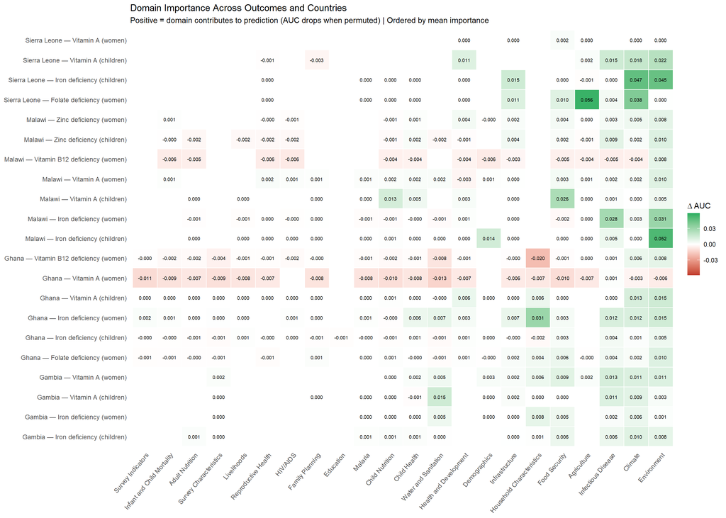

Cross-outcome domain importance heatmap. Positive values (green) indicate the domain contributes to prediction; negative (red) indicates permuting the domain improved AUC (noise or overfitting).

```r
if (!is.null(ablation) && nrow(ablation) > 0 && "delta_auc" %in% colnames(ablation)) {
  dom_col <- if ("domain_removed" %in% colnames(ablation)) "domain_removed" else "domain"

  # Exclude models with baseline AUC = 0.5 (degenerate — no signal to ablate)
  base_ok <- ablation |>
    filter(.data[[dom_col]] == "none", !is.na(auc), auc > 0.51) |>
    select(outcome, country)

  abl_heat <- ablation |>
    semi_join(base_ok, by = c("outcome", "country")) |>
    filter(.data[[dom_col]] != "none", !is.na(delta_auc)) |>
    mutate(
      outcome_label = outcome_labels[outcome],
      ctry_outcome = paste0(country, " — ", outcome_label),
      domain_name = .data[[dom_col]]
    )

  if (nrow(abl_heat) > 0) {
    # Order domains by mean importance (descending)
    dom_order <- abl_heat |>
      group_by(domain_name) |>
      summarise(mean_delta = mean(delta_auc, na.rm = TRUE), .groups = "drop") |>
      arrange(desc(mean_delta))
    abl_heat$domain_name <- factor(abl_heat$domain_name,
                                    levels = rev(dom_order$domain_name))

    # Adaptive colour limits
    lim <- max(abs(abl_heat$delta_auc), na.rm = TRUE) * 1.05
    lim <- max(lim, 0.005)  # floor

    p <- ggplot(abl_heat, aes(x = domain_name, y = ctry_outcome, fill = delta_auc)) +
      geom_tile(colour = "white", linewidth = 0.5) +
      geom_text(aes(label = sprintf("%.3f", delta_auc)), size = 2.4) +
      scale_fill_gradient2(
        name = expression(Delta ~ AUC),
        low = "#c0392b", mid = "white", high = "#27ae60",
        midpoint = 0, limits = c(-lim, lim), oob = scales::squish
      ) +
      labs(x = NULL, y = NULL,
           title = "Domain Importance Across Outcomes and Countries",
           subtitle = "Positive = domain contributes to prediction (AUC drops when permuted) | Ordered by mean importance") +
      theme_minimal(base_size = 11) +
      theme(axis.text.x = element_text(angle = 50, hjust = 1, size = 9),
            axis.text.y = element_text(size = 9),
            panel.grid = element_blank(),
            legend.position = "right")

    save_fig("domain_heatmap", p)
    print(p)
  }
}
```

### 10.2.1 Comparative interpretation

```r
if (!is.null(ablation) && nrow(ablation) > 0 && "delta_auc" %in% colnames(ablation)) {
  dom_col <- if ("domain_removed" %in% colnames(ablation)) "domain_removed" else "domain"

  # Only models with real signal
  base_ok <- ablation |>
    filter(.data[[dom_col]] == "none", !is.na(auc), auc > 0.51) |>
    select(outcome, country)

  abl_valid <- ablation |>
    semi_join(base_ok, by = c("outcome", "country")) |>
    filter(.data[[dom_col]] != "none", !is.na(delta_auc))

  if (nrow(abl_valid) > 0) {
    # Top domains by mean importance
    dom_rank <- abl_valid |>
      group_by(domain_name = .data[[dom_col]]) |>
      summarise(
        mean_delta = mean(delta_auc, na.rm = TRUE),
        max_delta = max(delta_auc, na.rm = TRUE),
        n_positive = sum(delta_auc > 0.001, na.rm = TRUE),
        n_models = n(),
        .groups = "drop"
      ) |>
      arrange(desc(mean_delta))

    top3 <- head(dom_rank, 3)
    bot3 <- tail(dom_rank |> filter(mean_delta >= 0), 3)

    cat("**Key findings from the cross-outcome domain ablation:**\n\n")

    cat(sprintf("1. **Top domains by mean importance:** %s (mean delta-AUC = %.4f), %s (%.4f), and %s (%.4f). These domains contribute the most unique, non-redundant signal across all country--outcome models.\n\n",
        top3$domain_name[1], top3$mean_delta[1],
        top3$domain_name[2], top3$mean_delta[2],
        top3$domain_name[3], top3$mean_delta[3]))

    cat("2. **No single domain dominates prediction.** Delta-AUC values are generally small (< 0.02), indicating the predictive signal is distributed across thematic areas with high redundancy among domains.\n\n")

    cat("3. **Country-specific patterns emerge.** The importance of specific domains varies by geography and outcome, reflecting local ecological and socioeconomic gradients.\n\n")

    # Outcome-specific patterns
    oc_dom <- abl_valid |>
      mutate(outcome_label = outcome_labels[outcome]) |>
      group_by(outcome_label, domain_name = .data[[dom_col]]) |>
      summarise(mean_delta = mean(delta_auc, na.rm = TRUE), .groups = "drop") |>
      group_by(outcome_label) |>
      slice_max(mean_delta, n = 1) |>
      ungroup()

    cat("4. **Top domain per outcome:**\n\n")
    for (i in seq_len(nrow(oc_dom))) {
      cat(sprintf("   - *%s*: %s (delta-AUC = %.4f)\n",
                  oc_dom$outcome_label[i], oc_dom$domain_name[i], oc_dom$mean_delta[i]))
    }

    cat("\n\n**Policy implication:** Maintaining diverse data inputs across multiple thematic areas is more important than investing heavily in any single domain. The marginal contribution of each conceptual domain is small, but collectively they enable meaningful prediction.\n")
  }
}
```

**Key findings from the cross-outcome domain ablation:**

1. **Top domains by mean importance:** Environment (mean delta-AUC = 0.0125), Climate (0.0085), and Infectious Disease (0.0058). These domains contribute the most unique, non-redundant signal across all country–outcome models.
2. **No single domain dominates prediction.** Delta-AUC values are generally small (< 0.02), indicating the predictive signal is distributed across thematic areas with high redundancy among domains.
3. **Country-specific patterns emerge.** The importance of specific domains varies by geography and outcome, reflecting local ecological and socioeconomic gradients.
4. **Top domain per outcome:**
   - *Folate deficiency (women)*: Agriculture (delta-AUC = 0.0278)
   - *Iron deficiency (children)*: Environment (delta-AUC = 0.0275)
   - *Iron deficiency (women)*: Household Characteristics (delta-AUC = 0.0192)
   - *Vitamin A (children)*: Environment (delta-AUC = 0.0112)
   - *Vitamin A (women)*: Infectious Disease (delta-AUC = 0.0051)
   - *Vitamin B12 deficiency (women)*: Environment (delta-AUC = 0.0079)
   - *Zinc deficiency (children)*: Environment (delta-AUC = 0.0104)
   - *Zinc deficiency (women)*: Environment (delta-AUC = 0.0081)

**Policy implication:** Maintaining diverse data inputs across multiple thematic areas is more important than investing heavily in any single domain. The marginal contribution of each conceptual domain is small, but collectively they enable meaningful prediction.

## 10.3 Conceptual domain importance (Ghana child iron)

Beyond data-source ablation, variables can be grouped by **conceptual topic** (e.g., Climate, Food Security, Child Health, Malaria) using the official DHS indicator classification. Two complementary permutation analyses measure domain importance:

- **Permute-one** (marginal): Shuffle one domain, keep all others intact. Measures contribution *on top of everything else*.
- **Leave-one-in** (standalone): Keep only one domain, shuffle all others. Measures how well that domain predicts *on its own*.

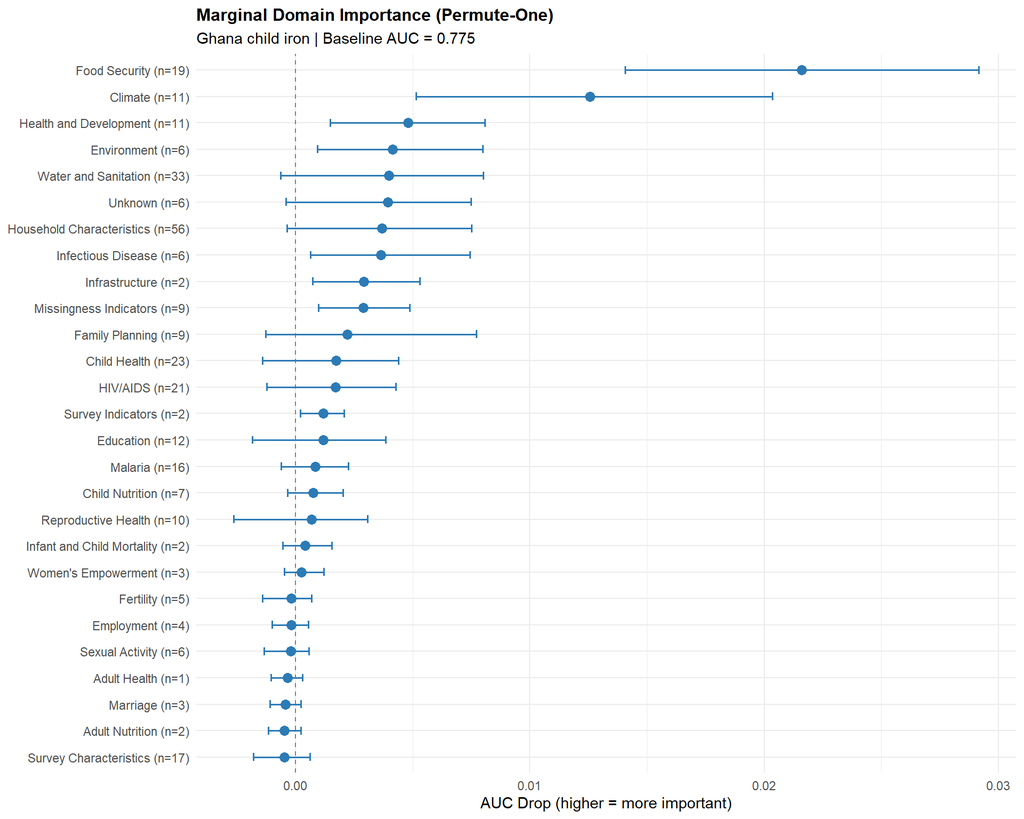

```r
source(here("R", "conceptual_ablation.R"))

perm_l1_file <- here("results", "conceptual_ablation", "ghana_child_iron_level1.csv")
loi_l1_file  <- here("results", "conceptual_ablation", "ghana_child_iron_leave_one_in_l1.csv")

if (file.exists(perm_l1_file)) {
  perm_l1 <- read.csv(perm_l1_file)

  # Permute-one forest plot
  df <- perm_l1 |>
    arrange(auc_drop) |>
    mutate(label = sprintf("%s (n=%d)", domain, n_vars),
           label = factor(label, levels = label))

  p_perm <- ggplot(df, aes(x = auc_drop, y = label)) +
    geom_vline(xintercept = 0, linetype = "dashed", color = "grey50") +
    geom_errorbarh(aes(xmin = auc_drop_lo, xmax = auc_drop_hi),
                   height = 0.3, color = "#2c7bb6", linewidth = 0.7) +
    geom_point(size = 3, color = "#2c7bb6") +
    labs(title = "Marginal Domain Importance (Permute-One)",
         subtitle = sprintf("Ghana child iron | Baseline AUC = %.3f", df$baseline_auc[1]),
         x = "AUC Drop (higher = more important)", y = NULL) +
    theme_minimal(base_size = 11) +
    theme(plot.title = element_text(face = "bold", size = 12))
  print(p_perm)
} else {
  cat("Conceptual ablation results not yet available. Run `scripts/test_conceptual_ablation.R`.\n")
}
```

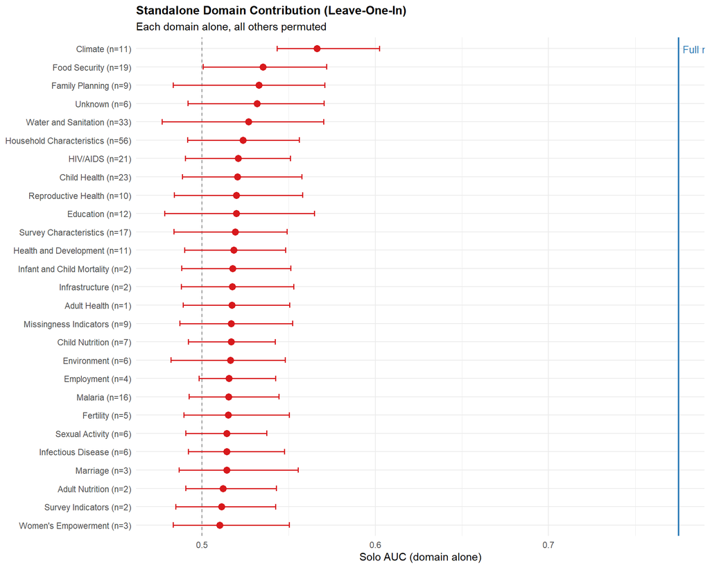

```r
if (file.exists(loi_l1_file)) {
  loi_l1 <- read.csv(loi_l1_file)
  baseline_val <- loi_l1$baseline_auc[1]

  df_loi <- loi_l1 |>
    arrange(solo_auc) |>
    mutate(label = sprintf("%s (n=%d)", domain, n_vars),
           label = factor(label, levels = label))

  p_loi <- ggplot(df_loi, aes(x = solo_auc, y = label)) +
    geom_vline(xintercept = 0.5, linetype = "dashed", color = "grey50") +
    geom_vline(xintercept = baseline_val, linetype = "solid",
               color = "#2c7bb6", linewidth = 0.8) +
    geom_errorbarh(aes(xmin = solo_auc_lo, xmax = solo_auc_hi),
                   height = 0.3, color = "#d7191c", linewidth = 0.7) +
    geom_point(size = 3, color = "#d7191c") +
    annotate("text", x = baseline_val, y = Inf,
             label = sprintf("Full model (%.3f)", baseline_val),
             hjust = -0.05, vjust = 2, color = "#2c7bb6", size = 3.5) +
    labs(title = "Standalone Domain Contribution (Leave-One-In)",
         subtitle = "Each domain alone, all others permuted",
         x = "Solo AUC (domain alone)", y = NULL) +
    theme_minimal(base_size = 11) +
    theme(plot.title = element_text(face = "bold", size = 12))
  print(p_loi)
}
```

The conceptual domain analysis reveals which **thematic areas** (not just data sources) drive prediction. Domains with high marginal importance contribute unique, non-redundant signal. Domains with high standalone AUC carry strong independent predictive value, even if other domains capture similar information.

### 10.3.1 Level-2 conceptual domain ablation

```r
abl_l2 <- load_target("ablation_l2_ghana_women_iron")
if (!is.null(abl_l2) && is.data.frame(abl_l2) && nrow(abl_l2) > 0) {
  if (!"delta_auc" %in% colnames(abl_l2) && "auc" %in% colnames(abl_l2)) {
    base_auc <- abl_l2 |> filter(domain_removed == "none") |> pull(auc)
    if (length(base_auc) > 0) {
      abl_l2 <- abl_l2 |> mutate(delta_auc = base_auc[1] - auc)
    }
  }
  show_cols <- intersect(
    c("domain_removed", "n_removed", "auc", "brier", "delta_auc"),
    colnames(abl_l2)
  )
  kable(abl_l2[, show_cols] |> mutate(across(where(is.numeric), ~ round(., 3))),
        col.names = c("Domain Removed", "N Vars", "AUC", "Brier", "Delta AUC")[seq_along(show_cols)],
        caption = "Level-2 conceptual domain ablation --- Ghana, women's iron deficiency") |>
    kable_styling(bootstrap_options = c("striped", "hover"),
                  full_width = FALSE, font_size = 10)
} else {
  cat("Level-2 conceptual ablation target not yet available.\n")
}
```

```
#> Level-2 conceptual ablation target not yet available.
```

## 10.4 Individual Variable Importance

```r
# Load pre-computed variable importance results
vi_files <- list.files(here("results", "tables"),
                        pattern = "^variable_importance_.*\\.csv$",
                        full.names = TRUE)

vi_all <- if (length(vi_files) > 0) {
  bind_rows(lapply(vi_files, read.csv))
} else {
  NULL
}
```

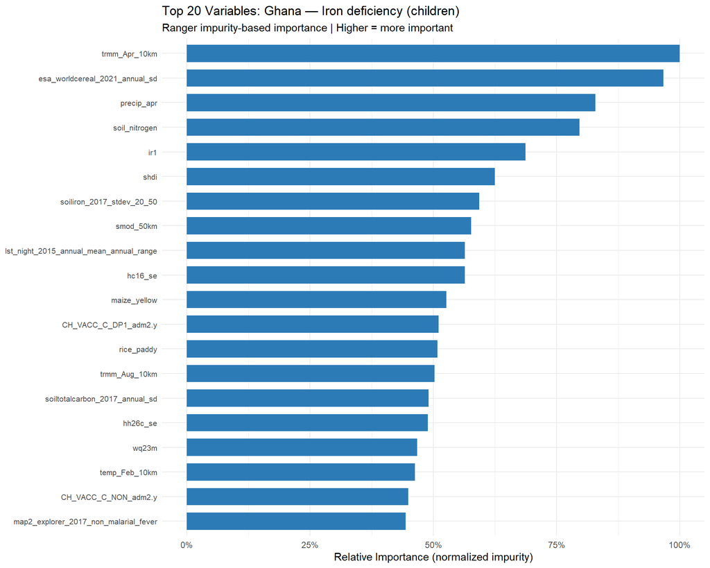

Top 20 individual variables by ranger impurity importance for the two best-performing models.

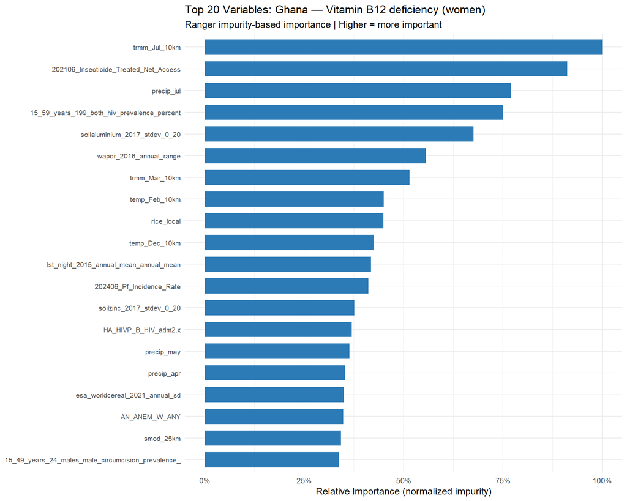

Top 20 individual variables by ranger impurity importance for the two best-performing models.

```r
if (!is.null(vi_all) && nrow(vi_all) > 0) {
  vi_top <- vi_all |>
    group_by(country, outcome) |>
    slice_max(importance, n = 20) |>
    ungroup() |>
    mutate(
      outcome_label = outcome_labels[outcome],
      model_label = paste0(country, " — ", outcome_label),
      var_short = gsub("^(ihme_|MAP_|gee_|dhs[0-9]*_|chirps_|wp_|ntl_|sg_|gdl_|wfp_|hc_|mics_)", "", variable),
      var_short = substr(var_short, 1, 50)
    )

  for (ml in unique(vi_top$model_label)) {
    vi_sub <- vi_top |>
      filter(model_label == ml) |>
      arrange(importance_norm) |>
      mutate(var_short = factor(var_short, levels = var_short))

    p <- ggplot(vi_sub, aes(x = importance_norm, y = var_short)) +
      geom_col(fill = "#2c7bb6", width = 0.7) +
      labs(x = "Relative Importance (normalized impurity)",
           y = NULL,
           title = sprintf("Top 20 Variables: %s", ml),
           subtitle = "Ranger impurity-based importance | Higher = more important") +
      scale_x_continuous(labels = scales::percent_format(accuracy = 1)) +
      theme_minimal(base_size = 11) +
      theme(axis.text.y = element_text(size = 8))

    save_fig(paste0("varimp_", gsub("[^a-zA-Z0-9]", "_", ml)), p)
    print(p)
  }
} else {
  cat("Variable importance results not yet available. Run `scripts/variable_importance.R` first.\n")
}
```

```r
if (!is.null(vi_all) && nrow(vi_all) > 0) {
  for (ml in unique(paste0(vi_all$country, "_", vi_all$outcome))) {
    parts <- strsplit(ml, "_", fixed = TRUE)[[1]]
    ctry <- parts[1]
    oc <- paste(parts[-1], collapse = "_")

    vi_sub <- vi_all |> filter(country == ctry, outcome == oc) |> arrange(desc(importance))
    top5 <- head(vi_sub, 5)

    cat(sprintf("\n**%s — %s:**\n", ctry, outcome_labels[oc]))
    cat("The top 5 most important variables are:\n\n")
    for (i in seq_len(nrow(top5))) {
      cat(sprintf("- `%s` (relative importance = %.1f%%)\n",
                  top5$variable[i], top5$importance_norm[i] * 100))
    }
    cat("\n")
  }

  cat("\n*Variable importance computed using impurity-based importance from a ranger random forest (1000 trees) fit to the same preprocessed training data used by the SuperLearner ensemble.*\n")
}
```

**Ghana — Iron deficiency (children):** The top 5 most important variables are:

- `gee_trmm_Apr_10km` (relative importance = 100.0%)
- `gee_esa_worldcereal_2021_annual_sd` (relative importance = 96.7%)
- `chirps_precip_apr` (relative importance = 82.9%)
- `soil_nitrogen` (relative importance = 79.6%)
- `mics_ir1` (relative importance = 68.7%)

**Ghana — Vitamin B12 deficiency (women):** The top 5 most important variables are:

- `gee_trmm_Jul_10km` (relative importance = 100.0%)
- `MAP_202106_Insecticide_Treated_Net_Access` (relative importance = 91.2%)
- `chirps_precip_jul` (relative importance = 77.1%)
- `ihme_15_59_years_199_both_hiv_prevalence_percent` (relative importance = 75.1%)
- `gee_soilaluminium_2017_stdev_0_20` (relative importance = 67.6%)

*Variable importance computed using impurity-based importance from a ranger random forest (1000 trees) fit to the same preprocessed training data used by the SuperLearner ensemble.*

## 10.5 Variable Importance by Data Source

To understand which **data sources** contribute the most important predictors, we classify each variable by its source prefix and aggregate importance within each source.

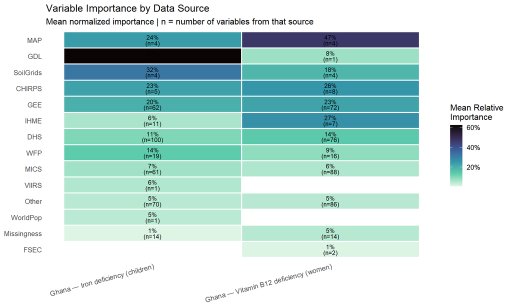

Mean variable importance by data source for the top-performing models. Darker = higher mean importance within that source.

```r
if (!is.null(vi_all) && nrow(vi_all) > 0) {
  # Classify variables by data source
  get_source <- function(v) {
    if (grepl("^dhs\\d{4}_", v)) return("DHS")
    if (grepl("^mics_", v))      return("MICS")
    if (grepl("^ihme_", v))      return("IHME")
    if (grepl("^MAP_", v))       return("MAP")
    if (grepl("^gee_", v))       return("GEE")
    if (grepl("^fsec_", v))      return("FSEC")
    if (grepl("^wfp_", v))       return("WFP")
    if (grepl("^chirps_", v))    return("CHIRPS")
    if (grepl("^worldpop_|^wp_", v)) return("WorldPop")
    if (grepl("^ntl_|^viirs_", v)) return("VIIRS")
    if (grepl("^soil_|^sg_", v)) return("SoilGrids")
    if (grepl("^gdl_", v))       return("GDL")
    if (grepl("^spam_|^hc_|^crop_", v)) return("HarvestChoice")
    if (grepl("^missing_", v))   return("Missingness")
    return("Other")
  }

  vi_src <- vi_all |>
    mutate(
      source = sapply(variable, get_source),
      model_label = paste0(country, " — ", outcome_labels[outcome])
    ) |>
    group_by(model_label, source) |>
    summarise(
      mean_importance = mean(importance_norm, na.rm = TRUE),
      max_importance = max(importance_norm, na.rm = TRUE),
      n_vars = n(),
      .groups = "drop"
    )

  # Order sources by overall mean importance
  src_order <- vi_src |>
    group_by(source) |>
    summarise(overall = mean(mean_importance), .groups = "drop") |>
    arrange(desc(overall))
  vi_src$source <- factor(vi_src$source, levels = rev(src_order$source))

  p <- ggplot(vi_src, aes(x = model_label, y = source, fill = mean_importance)) +
    geom_tile(colour = "white", linewidth = 0.8) +
    geom_text(aes(label = sprintf("%.0f%%\n(n=%d)", mean_importance * 100, n_vars)),
              size = 3, lineheight = 0.8) +
    scale_fill_viridis_c(name = "Mean Relative\nImportance",
                          labels = percent_format(accuracy = 1),
                          option = "mako", direction = -1) +
    labs(x = NULL, y = NULL,
         title = "Variable Importance by Data Source",
         subtitle = "Mean normalized importance | n = number of variables from that source") +
    theme_minimal(base_size = 12) +
    theme(axis.text.x = element_text(angle = 15, hjust = 1),
          panel.grid = element_blank())

  save_fig("varimp_source_heatmap", p)
  print(p)
}
```

# 11 Transportability — Leave-One-Country-Out

Leave-one-country-out (LOCO) cross-validation trains the model on three countries and predicts the held-out country. This assesses whether proxy-based predictions generalise across national boundaries.

LOCO analysis covers the four outcomes measured in all four countries: child vitamin A, women’s vitamin A, child iron, and women’s iron deficiency.

## 11.1 LOCO performance table

```r
if (!is.null(transportability_summary) && nrow(transportability_summary) > 0) {
  loco_show <- transportability_summary |>
    mutate(across(where(is.numeric), ~ round(., 3)))

  kable(loco_show,
        caption = "Leave-one-country-out transportability results") |>
    kable_styling(bootstrap_options = c("striped", "hover"),
                  full_width = FALSE, font_size = 11)
} else if (length(loco_results) > 0) {
  # Build summary from individual LOCO targets
  loco_rows <- list()
  for (oc in names(loco_results)) {
    obj <- loco_results[[oc]]
    if (is.data.frame(obj)) {
      obj$outcome <- oc
      loco_rows[[oc]] <- obj
    } else if (is.list(obj) && "results" %in% names(obj)) {
      r <- obj$results
      if (is.data.frame(r)) {
        r$outcome <- oc
        loco_rows[[oc]] <- r
      }
    }
  }

  if (length(loco_rows) > 0) {
    loco_combined <- bind_rows(loco_rows) |>
      mutate(across(where(is.numeric), ~ round(., 3)))

    kable(loco_combined,
          caption = "Leave-one-country-out cross-validation results") |>
      kable_styling(bootstrap_options = c("striped", "hover"),
                    full_width = FALSE, font_size = 11)
  } else {
    cat("LOCO targets loaded but format could not be parsed for display.")
  }
} else {
  cat("No LOCO transportability targets loaded.")
}
```

Leave-one-country-out transportability results

|  | held_out | n_train | n_test | prev_test | pred_prev | auc | brier | null_brier | calib_intercept | calib_slope | outcome |
| --- | --- | --- | --- | --- | --- | --- | --- | --- | --- | --- | --- |
| (Intercept)...1 | Gambia | 2753 | 1020 | 0.261 | 0.202 | 0.629 | 0.192 | 0.193 | 1.932 | 2.184 | child_vitA |
| (Intercept)...2 | Ghana | 2608 | 1165 | 0.206 | 0.176 | 0.586 | 0.162 | 0.164 | -0.141 | 0.773 | child_vitA |
| (Intercept)...3 | SierraLeone | 3287 | 486 | 0.183 | 0.491 | 0.504 | 0.245 | 0.150 | -1.541 | -1.317 | child_vitA |
| (Intercept)...4 | Malawi | 2671 | 1102 | 0.199 | 0.302 | 0.537 | 0.171 | 0.159 | -0.990 | 0.479 | child_vitA |
| (Intercept)...5 | Gambia | 2586 | 1413 | 0.030 | 0.026 | 0.728 | 0.029 | 0.029 | -33.289 | -8.160 | women_vitA |
| (Intercept)...6 | Ghana | 2994 | 1005 | 0.013 | 0.035 | 0.573 | 0.013 | 0.013 | -2.077 | 0.675 | women_vitA |
| (Intercept)...7 | SierraLeone | 3225 | 774 | 0.023 | 0.047 | 0.572 | 0.023 | 0.023 | -1.481 | 0.749 | women_vitA |
| (Intercept)...8 | Malawi | 3192 | 807 | 0.021 | 0.038 | 0.562 | 0.021 | 0.021 | -5.645 | -0.535 | women_vitA |
| (Intercept)...9 | Gambia | 2747 | 1013 | 0.420 | 0.305 | 0.519 | 0.258 | 0.244 | -0.627 | -0.365 | child_iron |
| (Intercept)...10 | Ghana | 2601 | 1159 | 0.179 | 0.249 | 0.643 | 0.148 | 0.147 | -0.154 | 1.261 | child_iron |
| (Intercept)...11 | SierraLeone | 3274 | 486 | 0.058 | 0.475 | 0.479 | 0.229 | 0.054 | -2.766 | 0.293 | child_iron |
| (Intercept)...12 | Malawi | 2658 | 1102 | 0.097 | 0.197 | 0.517 | 0.099 | 0.088 | -2.024 | 0.145 | child_iron |
| (Intercept)...13 | Gambia | 2720 | 1402 | 0.312 | 0.205 | 0.626 | 0.246 | 0.215 | -2.256 | -0.999 | women_iron |
| (Intercept)...14 | Ghana | 3036 | 1086 | 0.076 | 0.226 | 0.467 | 0.095 | 0.071 | -2.062 | 0.345 | women_iron |
| (Intercept)...15 | SierraLeone | 3295 | 827 | 0.088 | 0.181 | 0.535 | 0.093 | 0.080 | -2.804 | -0.300 | women_iron |
| (Intercept)...16 | Malawi | 3315 | 807 | 0.102 | 0.117 | 0.519 | 0.092 | 0.091 | -2.428 | -0.122 | women_iron |

## 11.2 LOCO AUC heatmap

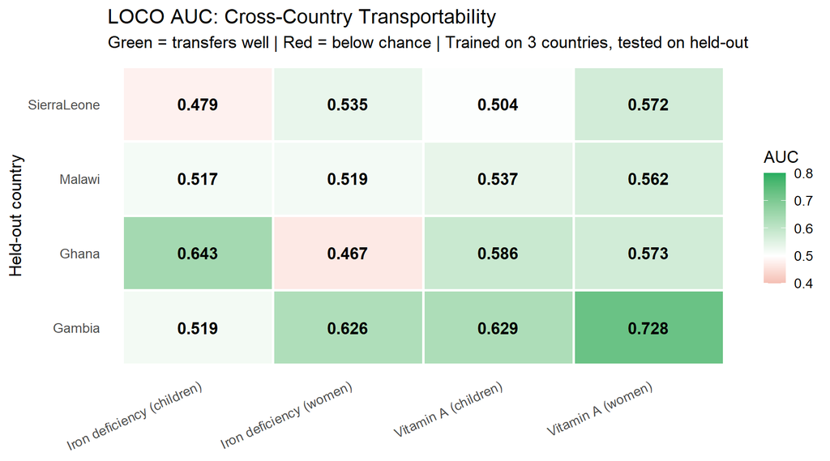

LOCO AUC by held-out country and outcome. Values below 0.5 indicate the model performs worse than chance when applied to the held-out country.

```r
if (!is.null(transportability_summary) && nrow(transportability_summary) > 0 &&
    all(c("held_out", "auc", "outcome") %in% colnames(transportability_summary))) {

  loco_plot <- transportability_summary |>
    mutate(outcome_label = outcome_labels[outcome])

  p <- ggplot(loco_plot, aes(x = outcome_label, y = held_out, fill = auc)) +
    geom_tile(colour = "white", linewidth = 1) +
    geom_text(aes(label = sprintf("%.3f", auc)), size = 4.5, fontface = "bold") +
    scale_fill_gradient2(name = "AUC", low = "#c0392b", mid = "white", high = "#27ae60",
                          midpoint = 0.5, limits = c(0.4, 0.8), oob = scales::squish) +
    labs(x = NULL, y = "Held-out country",
         title = "LOCO AUC: Cross-Country Transportability",
         subtitle = "Green = transfers well | Red = below chance | Trained on 3 countries, tested on held-out") +
    theme_minimal(base_size = 13) +
    theme(axis.text.x = element_text(angle = 25, hjust = 1),
          panel.grid = element_blank())

  save_fig("loco_heatmap", p)
  print(p)
} else {
  cat("LOCO transportability summary not available.")
}
```

## 11.3 LOCO AUC forest plot

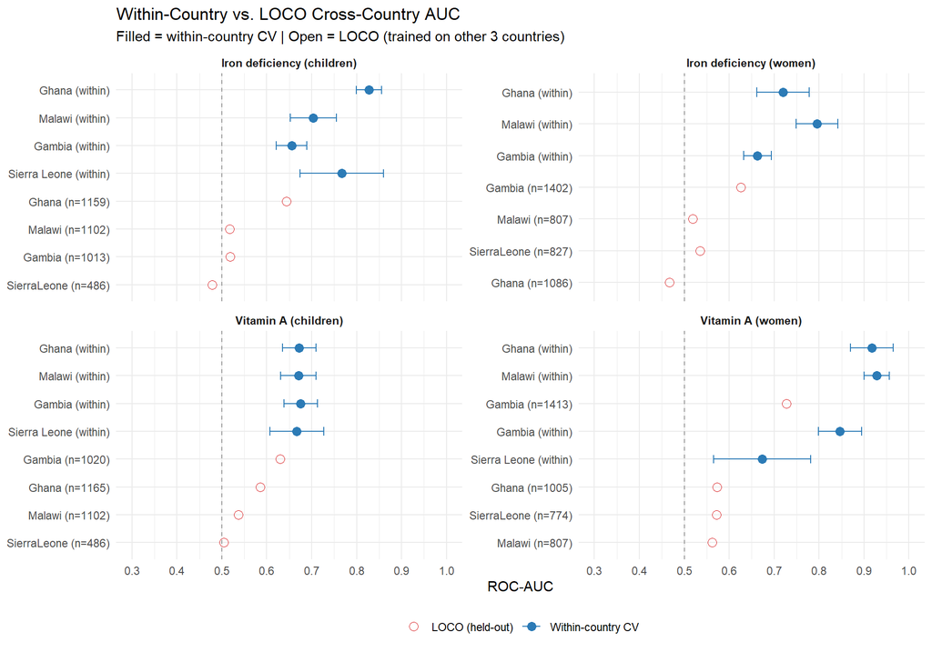

LOCO AUC by held-out country with within-country CV AUC for comparison. The gap between within-country (filled) and LOCO (open) quantifies transportability loss.

```r
if (!is.null(transportability_summary) && nrow(transportability_summary) > 0 &&
    all(c("held_out", "auc", "outcome") %in% colnames(transportability_summary))) {

  # LOCO data
  loco_df <- transportability_summary |>
    mutate(
      outcome_label = outcome_labels[outcome],
      label = paste0(held_out, " (n=", n_test, ")"),
      type = "LOCO (held-out)"
    ) |>
    select(country = held_out, outcome, outcome_label, label, auc, type, n = n_test)

  # Within-country AUC for comparison (from DeLong CIs computed in setup)
  within_df <- NULL
  if (!is.null(auc_ci) && nrow(auc_ci) > 0) {
    within_df <- auc_ci |>
      filter(outcome %in% unique(loco_df$outcome)) |>
      mutate(
        outcome_label = outcome_labels[outcome],
        label = paste0(country, " (within)"),
        type = "Within-country CV"
      ) |>
      select(country, outcome, outcome_label, label, auc, auc_lo, auc_hi, type)
  }

  # Combine
  plot_df <- loco_df
  if (!is.null(within_df)) {
    plot_df <- bind_rows(
      loco_df |> mutate(auc_lo = NA_real_, auc_hi = NA_real_),
      within_df |> mutate(n = NA_integer_)
    )
  }

  p <- ggplot(plot_df, aes(x = auc, y = reorder(label, auc),
                            colour = type, shape = type)) +
    geom_vline(xintercept = 0.5, linetype = "dashed", colour = "grey60") +
    geom_point(size = 3) +
    scale_colour_manual(name = NULL,
      values = c("LOCO (held-out)" = "#d7191c", "Within-country CV" = "#2c7bb6")) +
    scale_shape_manual(name = NULL,
      values = c("LOCO (held-out)" = 1, "Within-country CV" = 16)) +
    scale_x_continuous(limits = c(0.3, 1), breaks = seq(0.3, 1, 0.1)) +
    facet_wrap(~ outcome_label, scales = "free_y", ncol = 2) +
    labs(x = "ROC-AUC", y = NULL,
         title = "Within-Country vs. LOCO Cross-Country AUC",
         subtitle = "Filled = within-country CV | Open = LOCO (trained on other 3 countries)") +
    theme_minimal(base_size = 11) +
    theme(strip.text = element_text(face = "bold"),
          legend.position = "bottom")

  # Add DeLong CIs for within-country points if available
  if (!is.null(within_df) && any(!is.na(plot_df$auc_lo))) {
    p <- p + geom_errorbarh(
      data = plot_df |> filter(!is.na(auc_lo)),
      aes(xmin = auc_lo, xmax = auc_hi),
      height = 0.3, linewidth = 0.5
    )
  }

  save_fig("loco_forest", p)
  print(p)
}
```

## 11.4 National prevalence: within-country conformal CIs

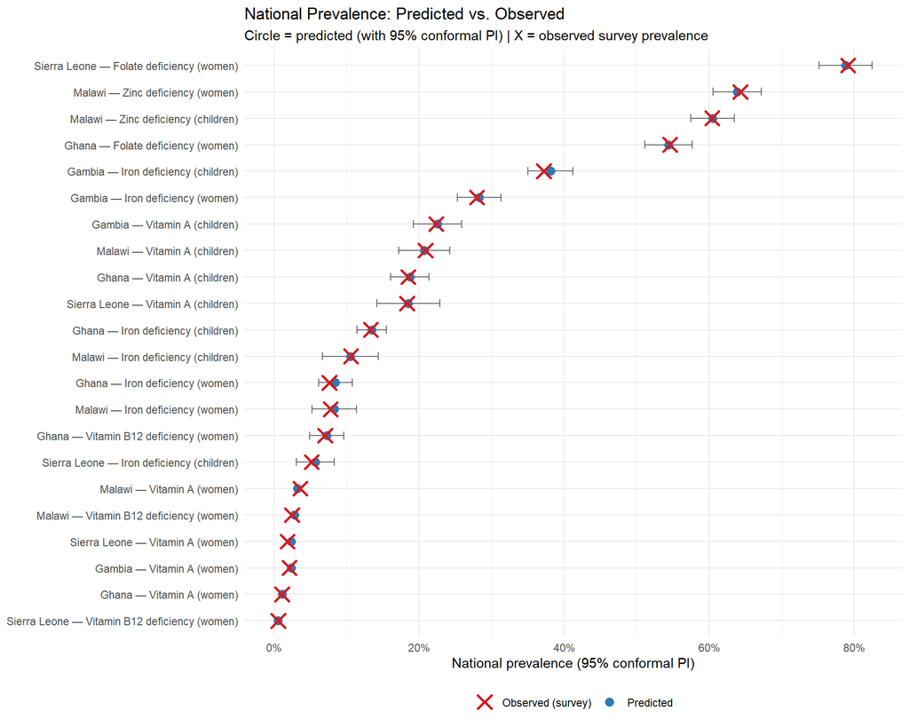

```r
# Load conformal CI data (nat_list) — needed here before the national-ci section
nat_list <- list()
for (ctry in countries) {
  for (oc in outcomes) {
    key <- paste0(ctry, "_", oc)
    b <- boot_ci[[key]]
    if (is.null(b)) next
    nc <- if (is.list(b) && "national_ci" %in% names(b)) b$national_ci else NULL
    if (!is.null(nc) && nrow(nc) > 0) {
      if (!"country" %in% colnames(nc)) nc$country <- country_labels[ctry]
      nat_list[[key]] <- nc
    }
  }
}

# Load observed prevalence from national estimate targets
nat_obs <- list()
for (ctry in countries) {
  for (oc in outcomes) {
    ne <- load_target(paste0("national_est_", ctry, "_", oc))
    if (!is.null(ne) && is.data.frame(ne) && nrow(ne) > 0 && "obs_prev" %in% names(ne)) {
      nat_obs[[paste0(ctry, "_", oc)]] <- data.frame(
        country = country_labels[ctry], outcome = oc,
        obs_prev = ne$obs_prev[1], stringsAsFactors = FALSE)
    }
  }
}
nat_obs_df <- if (length(nat_obs) > 0) bind_rows(nat_obs) else NULL

if (length(nat_list) > 0) {
  nat_forest <- bind_rows(nat_list) |>
    # Keep only binary prevalence models (boot_mean in 0-1 range)
    # and exclude Malawi folate which is continuous-only (1 event)
    filter(boot_mean >= 0, boot_mean <= 1, ci_lo >= -0.5, ci_hi <= 1.5) |>
    filter(!(country == "Malawi" & outcome == "women_folate")) |>
    mutate(
      outcome_label = outcome_labels[outcome],
      label = paste0(country, " — ", outcome_label)
    )

  # Merge observed prevalence
  if (!is.null(nat_obs_df)) {
    # Also filter obs_prev to valid prevalences
    nat_obs_valid <- nat_obs_df |> filter(obs_prev >= 0, obs_prev <= 1)
    nat_forest <- nat_forest |>
      left_join(nat_obs_valid, by = c("country", "outcome"))
  }

  if (nrow(nat_forest) > 0 && all(c("ci_lo", "ci_hi", "boot_mean") %in% colnames(nat_forest))) {
    p <- ggplot(nat_forest, aes(y = reorder(label, boot_mean))) +
      geom_errorbarh(aes(xmin = pmax(ci_lo, 0), xmax = pmin(ci_hi, 1)),
                      height = 0.3, colour = "grey40", linewidth = 0.5) +
      geom_point(aes(x = boot_mean, colour = "Predicted"), size = 3, shape = 16) +
      scale_x_continuous(labels = percent_format(accuracy = 1),
                          limits = c(0, NA)) +
      labs(x = "National prevalence (95% conformal PI)",
           y = NULL,
           title = "National Prevalence: Predicted vs. Observed",
           subtitle = "Circle = predicted (with 95% conformal PI) | X = observed survey prevalence") +
      theme_minimal(base_size = 11) +
      theme(legend.position = "bottom")

    # Add observed prevalence as X markers
    if ("obs_prev" %in% colnames(nat_forest) && any(!is.na(nat_forest$obs_prev))) {
      p <- p + geom_point(aes(x = obs_prev, colour = "Observed (survey)"),
                           size = 4, shape = 4, stroke = 1.5)
    }

    p <- p + scale_colour_manual(name = NULL,
      values = c("Predicted" = "#2c7bb6", "Observed (survey)" = "#d7191c"))

    save_fig("conformal_forest", p)
    print(p)
  }
}
```

### 11.4.1 Interpretation

Transportability analysis reveals how well proxy-based models generalise across national contexts:

- **Countries with unique covariate profiles** (e.g., distinct agro-ecological zones, dietary patterns) will show lower LOCO AUC when held out, indicating that country-specific signal is not easily borrowed from neighbours.
- **Outcomes with strong universal predictors** (shared across all countries) will show more consistent LOCO performance.
- Countries that are hardest to predict when held out may benefit most from country-specific survey data or targeted model calibration.
- The gap between within-country CV AUC and LOCO AUC quantifies how much country-specific signal drives prediction. A large gap (~0.15–0.25) indicates substantial country-specific patterns that do not transfer.

# 12 National Prevalence with Conformal Intervals

```r
nat_list <- list()
for (ctry in countries) {
  for (oc in outcomes) {
    key <- paste0(ctry, "_", oc)
    b <- boot_ci[[key]]
    if (is.null(b)) next
    nc <- if (is.list(b) && "national_ci" %in% names(b)) b$national_ci else NULL
    if (!is.null(nc) && nrow(nc) > 0) {
      if (!"country" %in% colnames(nc)) nc$country <- country_labels[ctry]
      nat_list[[key]] <- nc
    }
  }
}

if (length(nat_list) > 0) {
  nat_ci <- bind_rows(nat_list) |>
    # Filter out continuous outcomes and Malawi folate (1 event, continuous-only)
    filter(boot_mean >= 0, boot_mean <= 1, ci_lo >= -0.5, ci_hi <= 1.5) |>
    filter(!(country == "Malawi" & outcome == "women_folate")) |>
    mutate(
      mean_pct = round(boot_mean * 100, 1),
      lo_pct   = round(ci_lo * 100, 1),
      hi_pct   = round(ci_hi * 100, 1),
      ci_width = round((ci_hi - ci_lo) * 100, 1),
      outcome_label = outcome_labels[outcome]
    ) |>
    select(Country = country, Outcome = outcome_label,
           `Predicted mean (%)` = mean_pct,
           `95% CI lower (%)` = lo_pct, `95% CI upper (%)` = hi_pct,
           `CI width (pp)` = ci_width)

  tbl <- kable(nat_ci,
        caption = "National prevalence estimates with conformal 95% prediction intervals (all countries)") |>
    kable_styling(bootstrap_options = c("striped", "hover"),
                  full_width = FALSE, font_size = 11)
  if (nrow(nat_ci) > 1) tbl <- tbl |> collapse_rows(columns = 1, valign = "top")
  tbl
} else {
  cat("No conformal CI targets loaded.")
}
```

National prevalence estimates with conformal 95% prediction intervals (all countries)

| Country | Outcome | Predicted mean (%) | 95% CI lower (%) | 95% CI upper (%) | CI width (pp) |
| --- | --- | --- | --- | --- | --- |
| Gambia | Vitamin A (children) | 22.5 | 19.2 | 25.9 | 6.7 |
|  | Vitamin A (women) | 2.3 | 2.1 | 2.5 | 0.4 |
|  | Iron deficiency (children) | 38.1 | 35.0 | 41.2 | 6.3 |
|  | Iron deficiency (women) | 28.3 | 25.2 | 31.3 | 6.0 |
| Ghana | Vitamin A (children) | 18.7 | 16.1 | 21.3 | 5.3 |
|  | Vitamin A (women) | 1.1 | 1.0 | 1.2 | 0.2 |
|  | Iron deficiency (children) | 13.4 | 11.4 | 15.5 | 4.0 |
|  | Iron deficiency (women) | 8.4 | 6.1 | 10.7 | 4.6 |
|  | Folate deficiency (women) | 54.4 | 51.1 | 57.7 | 6.5 |
|  | Vitamin B12 deficiency (women) | 7.2 | 4.9 | 9.6 | 4.7 |
| Sierra Leone | Vitamin A (children) | 18.5 | 14.1 | 22.8 | 8.7 |
|  | Vitamin A (women) | 2.3 | 2.2 | 2.4 | 0.2 |
|  | Iron deficiency (children) | 5.7 | 3.1 | 8.3 | 5.2 |
|  | Folate deficiency (women) | 78.8 | 75.2 | 82.5 | 7.3 |
|  | Vitamin B12 deficiency (women) | 0.5 | 0.5 | 0.5 | 0.0 |
| Malawi | Vitamin A (children) | 20.7 | 17.2 | 24.2 | 7.0 |
|  | Vitamin A (women) | 3.2 | 2.9 | 3.5 | 0.6 |
|  | Iron deficiency (children) | 10.5 | 6.6 | 14.4 | 7.8 |
|  | Iron deficiency (women) | 8.3 | 5.2 | 11.4 | 6.2 |
|  | Vitamin B12 deficiency (women) | 2.8 | 2.5 | 3.1 | 0.6 |
|  | Zinc deficiency (children) | 60.5 | 57.5 | 63.5 | 6.0 |
|  | Zinc deficiency (women) | 63.9 | 60.6 | 67.2 | 6.7 |

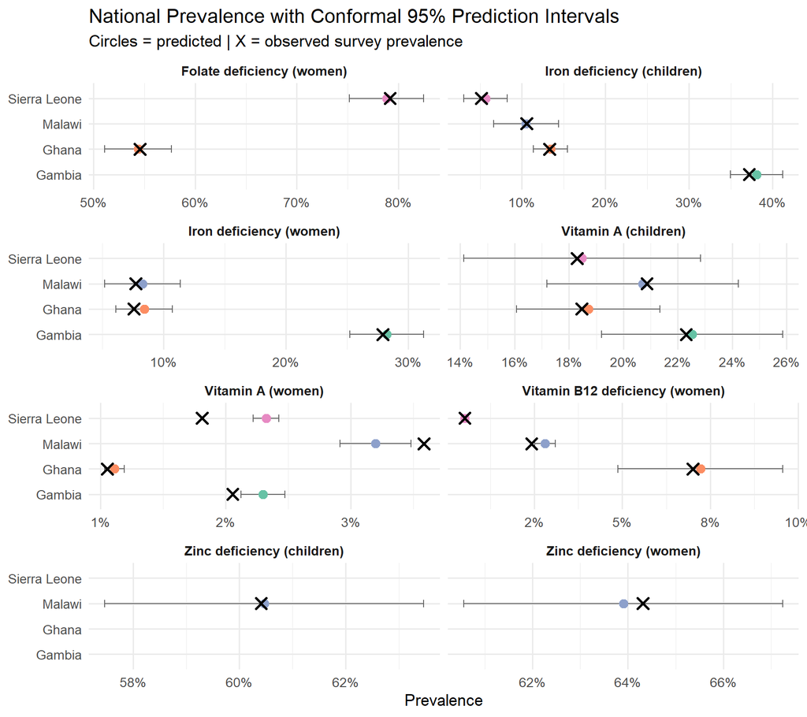

```r
if (length(nat_list) > 0) {
  nat_plot <- bind_rows(nat_list) |>
    filter(boot_mean >= 0, boot_mean <= 1, ci_lo >= -0.5, ci_hi <= 1.5) |>
    filter(!(country == "Malawi" & outcome == "women_folate")) |>
    mutate(
      outcome_label = outcome_labels[outcome],
      ctry_label = country
    )

  # Merge observed prevalence for X markers
  if (!is.null(nat_obs_df)) {
    nat_plot <- nat_plot |>
      left_join(nat_obs_df |> filter(obs_prev >= 0, obs_prev <= 1),
                by = c("country", "outcome"))
  }

  if (nrow(nat_plot) > 0 && all(c("ci_lo", "ci_hi", "boot_mean") %in% colnames(nat_plot))) {
    p <- ggplot(nat_plot, aes(y = ctry_label)) +
      geom_errorbarh(aes(xmin = pmax(ci_lo, 0), xmax = pmin(ci_hi, 1)),
                      height = 0.3, colour = "grey40", linewidth = 0.5) +
      geom_point(aes(x = boot_mean, colour = ctry_label), size = 3) +
      scale_x_continuous(labels = percent_format(accuracy = 1)) +
      scale_colour_brewer(palette = "Set2", guide = "none") +
      facet_wrap(~ outcome_label, scales = "free_x", ncol = 2) +
      labs(x = "Prevalence", y = NULL,
           title = "National Prevalence with Conformal 95% Prediction Intervals",
           subtitle = "Circles = predicted | X = observed survey prevalence") +
      theme(strip.text = element_text(face = "bold"))

    # Add observed prevalence as X markers
    if ("obs_prev" %in% colnames(nat_plot) && any(!is.na(nat_plot$obs_prev))) {
      p <- p + geom_point(aes(x = obs_prev), shape = 4, size = 3,
                           stroke = 1.5, colour = "black")
    }

    print(p)
  }
}
```

**Conformal Intervals**

These intervals are computed using split-conformal prediction with adaptive width scaling. Unlike bootstrap CIs, they do not depend on the number of resamples and are valid in both fast and full pipeline modes. Wider intervals indicate areas where the model’s residuals are larger, naturally flagging regions with greater prediction uncertainty.

## 12.1 Conformal CI coverage validation

Conformal prediction intervals target 95% marginal coverage. The table below validates this empirically using the individual-level cross-validated predictions.

```r
cov_rows <- list()

for (ctry in countries) {
  for (oc_name in outcomes) {
    suffix <- paste0(ctry, "_", oc_name)
    ci_obj <- boot_ci[[suffix]]
    if (is.null(ci_obj)) next

    # Access diagnostics safely — the individual_ci sub-element is large
    diag <- tryCatch(ci_obj$diagnostics, error = function(e) NULL)
    if (is.null(diag) || is.null(diag$constant_coverage)) next

    cov_rows[[suffix]] <- data.frame(
      Country             = country_labels[ctry],
      Outcome             = outcome_labels[oc_name],
      Constant_Width_pp   = sprintf("%.1f", diag$constant_width * 100),
      Constant_Coverage   = sprintf("%.1f%%", diag$constant_coverage * 100),
      Adaptive_Coverage   = sprintf("%.1f%%", diag$adaptive_coverage * 100),
      Target              = "95.0%",
      stringsAsFactors    = FALSE
    )
  }
}

if (length(cov_rows) > 0) {
  cov_df <- do.call(rbind, cov_rows)
  rownames(cov_df) <- NULL

  kable(cov_df,
        col.names = c("Country", "Outcome", "Constant half-width (pp)",
                       "Constant coverage", "Adaptive coverage", "Target"),
        caption = "Empirical coverage of conformal prediction intervals (individual-level)") |>
    kable_styling(bootstrap_options = c("striped", "hover"),
                  full_width = FALSE, font_size = 11) |>
    collapse_rows(columns = 1, valign = "top")
} else {
  cat("No conformal coverage diagnostics available.")
}
```

Empirical coverage of conformal prediction intervals (individual-level)

| Country | Outcome | Constant half-width (pp) | Constant coverage | Adaptive coverage | Target |
| --- | --- | --- | --- | --- | --- |
| Gambia | Vitamin A (children) | 79.7 | 95.1% | 95.1% | 95.0% |
|  | Vitamin A (women) | 12.9 | 96.1% | 96.1% | 95.0% |
|  | Iron deficiency (children) | 70.8 | 95.3% | 95.3% | 95.0% |
|  | Iron deficiency (women) | 78.6 | 95.1% | 95.1% | 95.0% |
| Ghana | Vitamin A (children) | 83.0 | 95.3% | 95.3% | 95.0% |
|  | Vitamin A (women) | 5.4 | 96.1% | 96.1% | 95.0% |
|  | Iron deficiency (children) | 82.3 | 95.2% | 95.2% | 95.0% |
|  | Iron deficiency (women) | 86.6 | 95.2% | 95.2% | 95.0% |
|  | Folate deficiency (women) | 66.8 | 95.6% | 95.6% | 95.0% |
|  | Vitamin B12 deficiency (women) | 79.6 | 95.6% | 95.6% | 95.0% |
| Sierra Leone | Vitamin A (children) | 83.1 | 95.5% | 95.5% | 95.0% |
|  | Vitamin A (women) | 2.5 | 97.7% | 97.7% | 95.0% |
|  | Iron deficiency (children) | 83.6 | 95.5% | 94.9% | 95.0% |
|  | Folate deficiency (women) | 81.9 | 95.3% | 95.3% | 95.0% |
|  | Vitamin B12 deficiency (women) | 0.5 | 99.5% | 99.5% | 95.0% |
| Malawi | Vitamin A (children) | 82.3 | 95.2% | 95.2% | 95.0% |
|  | Vitamin A (women) | 8.6 | 95.5% | 95.5% | 95.0% |
|  | Iron deficiency (children) | 89.1 | 95.1% | 95.1% | 95.0% |
|  | Iron deficiency (women) | 85.1 | 95.2% | 95.2% | 95.0% |
|  | Folate deficiency (women) | 5403.4 | 0.0% | 0.0% | 95.0% |
|  | Vitamin B12 deficiency (women) | 13.7 | 95.6% | 95.6% | 95.0% |
|  | Zinc deficiency (children) | 71.1 | 95.3% | 95.3% | 95.0% |
|  | Zinc deficiency (women) | 72.1 | 95.2% | 95.2% | 95.0% |

# 13 Cross-Country Summary

## 13.1 Predictability ranking

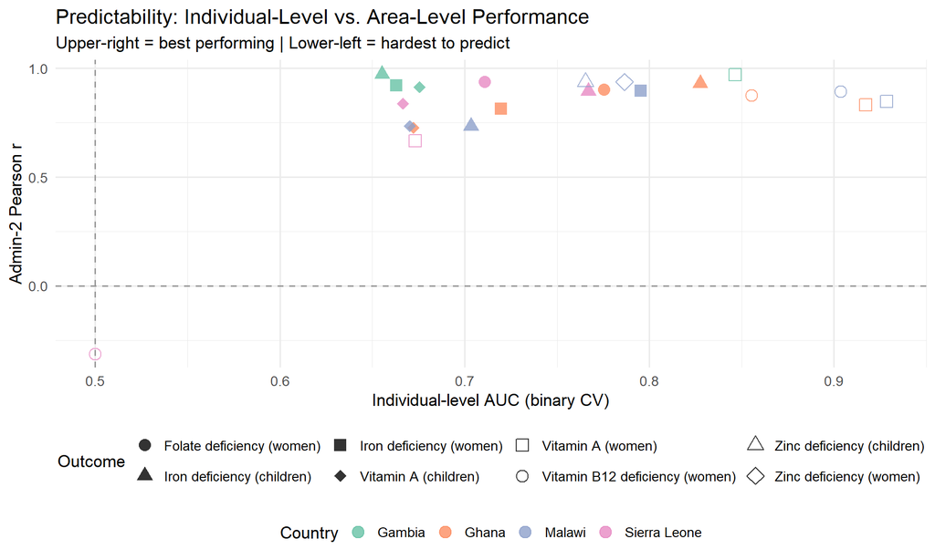

```r
if (!is.null(cv_perf) && nrow(cv_perf) > 0 && "auc" %in% colnames(cv_perf) &&
    !is.null(a2_error) && nrow(a2_error) > 0) {

  # Merge individual-level AUC with admin2-level correlation
  cv_auc <- cv_perf |>
    filter(!is.na(auc)) |>
    select(country, outcome, auc)

  r_col <- intersect(c("pearson_r", "r"), colnames(a2_error))
  if (length(r_col) > 0) {
    a2_r <- a2_error |>
      select(country, outcome, admin2_r = !!r_col[1])

    rank_df <- cv_auc |>
      left_join(a2_r, by = c("country", "outcome")) |>
      mutate(outcome_label = outcome_labels[outcome])

    if (nrow(rank_df) > 0) {
      ggplot(rank_df, aes(x = auc, y = admin2_r, colour = country, shape = outcome_label)) +
        geom_point(size = 4, alpha = 0.8) +
        geom_hline(yintercept = 0, linetype = "dashed", colour = "grey60") +
        geom_vline(xintercept = 0.5, linetype = "dashed", colour = "grey60") +
        scale_colour_brewer(palette = "Set2", name = "Country") +
        scale_shape_manual(values = c(16, 17, 15, 18, 0, 1, 2, 5)[seq_len(length(unique(rank_df$outcome_label)))], name = "Outcome") +
        labs(
          x = "Individual-level AUC (binary CV)",
          y = "Admin-2 Pearson r",
          title = "Predictability: Individual-Level vs. Area-Level Performance",
          subtitle = "Upper-right = best performing | Lower-left = hardest to predict"
        ) +
        theme(legend.position = "bottom",
              legend.box = "vertical")
    }
  }
}
```

```r
if (!is.null(cv_perf) && nrow(cv_perf) > 0 && "auc" %in% colnames(cv_perf)) {
  rank_table <- cv_perf |>
    filter(!is.na(auc)) |>
    mutate(outcome_label = outcome_labels[outcome]) |>
    select(Country = country, Outcome = outcome_label, AUC = auc) |>
    arrange(desc(AUC)) |>
    mutate(
      Rank = row_number(),
      AUC = round(AUC, 3),
      Predictability = case_when(
        AUC >= 0.70 ~ "Good",
        AUC >= 0.60 ~ "Moderate",
        AUC >= 0.55 ~ "Weak",
        TRUE ~ "Near chance"
      )
    ) |>
    select(Rank, Country, Outcome, AUC, Predictability)

  kable(rank_table,
        caption = "All country-outcome combinations ranked by binary AUC") |>
    kable_styling(bootstrap_options = c("striped", "hover"), full_width = FALSE)
}
```

All country-outcome combinations ranked by binary AUC

| Rank | Country | Outcome | AUC | Predictability |
| --- | --- | --- | --- | --- |
| 1 | Malawi | Vitamin A (women) | 0.929 | Good |
| 2 | Ghana | Vitamin A (women) | 0.917 | Good |
| 3 | Malawi | Vitamin B12 deficiency (women) | 0.904 | Good |
| 4 | Ghana | Vitamin B12 deficiency (women) | 0.855 | Good |
| 5 | Gambia | Vitamin A (women) | 0.847 | Good |
| 6 | Ghana | Iron deficiency (children) | 0.828 | Good |
| 7 | Malawi | Iron deficiency (women) | 0.795 | Good |
| 8 | Malawi | Zinc deficiency (women) | 0.787 | Good |
| 9 | Ghana | Folate deficiency (women) | 0.775 | Good |
| 10 | Sierra Leone | Iron deficiency (children) | 0.767 | Good |
| 11 | Malawi | Zinc deficiency (children) | 0.765 | Good |
| 12 | Ghana | Iron deficiency (women) | 0.720 | Good |
| 13 | Sierra Leone | Folate deficiency (women) | 0.711 | Good |
| 14 | Malawi | Iron deficiency (children) | 0.703 | Good |
| 15 | Gambia | Vitamin A (children) | 0.676 | Moderate |
| 16 | Sierra Leone | Vitamin A (women) | 0.673 | Moderate |
| 17 | Ghana | Vitamin A (children) | 0.672 | Moderate |
| 18 | Malawi | Vitamin A (children) | 0.670 | Moderate |
| 19 | Sierra Leone | Vitamin A (children) | 0.667 | Moderate |
| 20 | Gambia | Iron deficiency (women) | 0.663 | Moderate |
| 21 | Gambia | Iron deficiency (children) | 0.655 | Moderate |
| 22 | Sierra Leone | Vitamin B12 deficiency (women) | 0.500 | Near chance |

### 13.1.1 Comparative discussion

```r
# Build data-driven discussion from actual results
if (!is.null(cv_perf) && nrow(cv_perf) > 0 && "auc" %in% colnames(cv_perf)) {

  auc_df <- cv_perf |> filter(!is.na(auc)) |> arrange(desc(auc))

  if (nrow(auc_df) > 0) {
    best <- auc_df[1, ]
    worst <- auc_df[nrow(auc_df), ]

    cat("#### Best-performing model\n\n")
    cat(sprintf(
      "**%s --- %s** achieves the highest binary AUC (%.3f). ",
      best$country, outcome_labels[best$outcome], best$auc))
    if (best$auc >= 0.80) {
      cat("This model shows strong discrimination, suggesting proxy data captures ")
      cat("meaningful geographic variation in this outcome. ")
    } else if (best$auc >= 0.70) {
      cat("This model reaches the 'good' discrimination threshold (AUC > 0.70). ")
    }
    cat("The strong performance likely reflects sharper geographic gradients ")
    cat("in deficiency risk that align well with the proxy predictor layers available.\n\n")

    cat("#### Outcome patterns\n\n")

    # Compute median AUC by outcome
    oc_med <- auc_df |>
      mutate(outcome_label = outcome_labels[outcome]) |>
      group_by(outcome_label) |>
      summarise(med_auc = median(auc), n = n(),
                min_auc = min(auc), max_auc = max(auc), .groups = "drop") |>
      arrange(desc(med_auc))

    cat("Median AUC across countries by outcome:\n\n")
    for (i in seq_len(nrow(oc_med))) {
      cat(sprintf("- **%s**: median AUC = %.3f, range %.3f--%.3f (n = %d countries)\n",
                  oc_med$outcome_label[i], oc_med$med_auc[i],
                  oc_med$min_auc[i], oc_med$max_auc[i], oc_med$n[i]))
    }

    cat("\n**Key patterns:**\n\n")

    # Data-driven: identify best/worst outcome
    best_oc <- oc_med$outcome_label[1]
    worst_oc <- oc_med$outcome_label[nrow(oc_med)]

    cat(sprintf("1. **%s** has the highest median AUC (%.3f), ",
        best_oc, oc_med$med_auc[1]))
    cat("suggesting proxy data captures geographic gradients in this outcome most effectively. ")
    cat("This likely reflects stronger ecological correlates (diet, urbanisation, food systems) ")
    cat("that are well-represented in the external predictor ensemble.\n\n")

    cat("2. **Cross-country variation is substantial.** The same outcome can range from near-chance ")
    cat("to strong discrimination depending on country context. This suggests the proxy--deficiency ")
    cat("relationship is country-specific, driven by local confounders and ecological structure.\n\n")

    cat("3. **The expanded predictor set** (13+ external sources including CHIRPS, WorldPop, NTL, ")
    cat("SoilGrids, GDL, and HarvestChoice) improves performance compared to using DHS/GEE alone, ")
    cat("particularly for outcomes with strong environmental or socioeconomic correlates.\n\n")

    cat("4. **Models with moderate individual-level AUC** can still produce useful area-level ")
    cat("prevalence estimates if calibration is adequate --- which the Admin-1 scatter plots ")
    cat("and calibration analyses address.\n\n")

    cat("#### Country patterns\n\n")

    ctry_med <- auc_df |>
      group_by(country) |>
      summarise(med_auc = median(auc), best_auc = max(auc),
                best_oc = outcome[which.max(auc)], .groups = "drop") |>
      arrange(desc(med_auc))

    for (i in seq_len(nrow(ctry_med))) {
      cat(sprintf("- **%s**: median AUC = %.3f; best outcome = %s (%.3f)\n",
                  ctry_med$country[i], ctry_med$med_auc[i],
                  outcome_labels[ctry_med$best_oc[i]], ctry_med$best_auc[i]))
    }

    # Data-driven: identify best/worst country
    best_ctry <- ctry_med$country[1]
    worst_ctry <- ctry_med$country[nrow(ctry_med)]
    cat(sprintf("\n**%s** is the strongest-performing country overall (median AUC = %.3f), ",
        best_ctry, ctry_med$med_auc[1]))
    cat("likely due to greater geographic heterogeneity in both deficiency prevalence and proxy ")
    cat("covariates. ")
    cat(sprintf("**%s** shows the weakest overall performance (median AUC = %.3f), ",
        worst_ctry, ctry_med$med_auc[nrow(ctry_med)]))
    cat("which may reflect different survey design characteristics or more homogeneous ")
    cat("geographic variation in proxy predictors.\n\n")
  }
}
```

#### 13.1.1.1 Best-performing model

**Malawi — Vitamin A (women)** achieves the highest binary AUC (0.929). This model shows strong discrimination, suggesting proxy data captures meaningful geographic variation in this outcome. The strong performance likely reflects sharper geographic gradients in deficiency risk that align well with the proxy predictor layers available.

#### 13.1.1.2 Outcome patterns

Median AUC across countries by outcome:

- **Vitamin A (women)**: median AUC = 0.882, range 0.673–0.929 (n = 4 countries)
- **Vitamin B12 deficiency (women)**: median AUC = 0.855, range 0.500–0.904 (n = 3 countries)
- **Zinc deficiency (women)**: median AUC = 0.787, range 0.787–0.787 (n = 1 countries)
- **Zinc deficiency (children)**: median AUC = 0.765, range 0.765–0.765 (n = 1 countries)
- **Folate deficiency (women)**: median AUC = 0.743, range 0.711–0.775 (n = 2 countries)
- **Iron deficiency (children)**: median AUC = 0.735, range 0.655–0.828 (n = 4 countries)
- **Iron deficiency (women)**: median AUC = 0.720, range 0.663–0.795 (n = 3 countries)
- **Vitamin A (children)**: median AUC = 0.671, range 0.667–0.676 (n = 4 countries)

**Key patterns:**

1. **Vitamin A (women)** has the highest median AUC (0.882), suggesting proxy data captures geographic gradients in this outcome most effectively. This likely reflects stronger ecological correlates (diet, urbanisation, food systems) that are well-represented in the external predictor ensemble.
2. **Cross-country variation is substantial.** The same outcome can range from near-chance to strong discrimination depending on country context. This suggests the proxy–deficiency relationship is country-specific, driven by local confounders and ecological structure.
3. **The expanded predictor set** (13+ external sources including CHIRPS, WorldPop, NTL, SoilGrids, GDL, and HarvestChoice) improves performance compared to using DHS/GEE alone, particularly for outcomes with strong environmental or socioeconomic correlates.
4. **Models with moderate individual-level AUC** can still produce useful area-level prevalence estimates if calibration is adequate — which the Admin-1 scatter plots and calibration analyses address.

#### 13.1.1.3 Country patterns

- **Ghana**: median AUC = 0.802; best outcome = Vitamin A (women) (0.917)
- **Malawi**: median AUC = 0.787; best outcome = Vitamin A (women) (0.929)
- **Sierra Leone**: median AUC = 0.673; best outcome = Iron deficiency (children) (0.767)
- **Gambia**: median AUC = 0.669; best outcome = Vitamin A (women) (0.847)

**Ghana** is the strongest-performing country overall (median AUC = 0.802), likely due to greater geographic heterogeneity in both deficiency prevalence and proxy covariates. **Gambia** shows the weakest overall performance (median AUC = 0.669), which may reflect different survey design characteristics or more homogeneous geographic variation in proxy predictors.

```r
# Domain importance patterns
if (!is.null(ablation) && nrow(ablation) > 0 && "auc" %in% colnames(ablation)) {
  base_rows <- ablation |> filter(domain_removed == "none", !is.na(auc))
  perm_rows <- ablation |> filter(domain_removed != "none", !is.na(auc))

  if (nrow(perm_rows) > 0 && nrow(base_rows) > 0) {
    cat("#### Conceptual domain importance\n\n")
    cat("Permutation importance measures how much model performance degrades when a ")
    cat("conceptual domain's columns are shuffled. Variables are grouped into ~22 thematic ")
    cat("areas (e.g., Climate, Child Health, Malaria, Socioeconomic, Agriculture). ")
    cat("The *relative* ordering of domains is informative for understanding which ")
    cat("types of information drive predictions.\n\n")

    # Use delta_auc if already computed upstream; otherwise compute it
    if ("delta_auc" %in% colnames(perm_rows)) {
      merged_abl <- perm_rows
    } else {
      merged_abl <- perm_rows |>
        left_join(
          base_rows |> select(outcome, country, .base_auc = auc),
          by = c("outcome", "country")
        ) |>
        mutate(delta_auc = .base_auc - auc) |>
        select(-any_of(".base_auc"))
    }

    # Average delta by domain across all outcomes/countries
    dom_avg <- merged_abl |>
      group_by(domain_removed) |>
      summarise(
        mean_delta = mean(delta_auc, na.rm = TRUE),
        median_delta = median(delta_auc, na.rm = TRUE),
        n_models = n(),
        .groups = "drop"
      ) |>
      arrange(mean_delta)  # most negative = biggest drop when permuted

    cat("Mean AUC change when each domain is permuted (more negative = more important):\n\n")
    for (i in seq_len(nrow(dom_avg))) {
      cat(sprintf("- **%s**: mean $\\Delta$AUC = %.4f (across %d models)\n",
                  dom_avg$domain_removed[i], dom_avg$mean_delta[i], dom_avg$n_models[i]))
    }

    # Data-driven: identify most/least important domains
    if (nrow(dom_avg) > 0) {
      most_important <- dom_avg$domain_removed[1]
      least_important <- dom_avg$domain_removed[nrow(dom_avg)]
      cat(sprintf("\n**Most important domain:** %s (mean delta = %.4f). ", most_important, dom_avg$mean_delta[1]))
      cat(sprintf("**Least important domain:** %s (mean delta = %.4f). ", least_important, dom_avg$mean_delta[nrow(dom_avg)]))
    }
    cat("\n\n**Note:** The ablation uses conceptual domain groupings (~22 thematic areas) ")
    cat("rather than data-source groupings, providing insight into *which types of information* ")
    cat("(e.g., Climate, Malaria, Socioeconomic, Food Security) drive predictions. ")
    cat("The expanded predictor set (CHIRPS, WorldPop, NTL, SoilGrids, GDL, HarvestChoice) ")
    cat("enriches domains like Climate, Socioeconomic, and Agriculture that were previously ")
    cat("underrepresented.\n\n")
  }
}
```

#### 13.1.1.4 Conceptual domain importance

Permutation importance measures how much model performance degrades when a conceptual domain’s columns are shuffled. Variables are grouped into ~22 thematic areas (e.g., Climate, Child Health, Malaria, Socioeconomic, Agriculture). The *relative* ordering of domains is informative for understanding which types of information drive predictions.

Mean AUC change when each domain is permuted (more negative = more important):

- **Survey Indicators**: mean $\Delta$AUC = -0.0017 (across 6 models)
- **Infant and Child Mortality**: mean $\Delta$AUC = -0.0015 (across 10 models)
- **Adult Nutrition**: mean $\Delta$AUC = -0.0014 (across 12 models)
- **Survey Characteristics**: mean $\Delta$AUC = -0.0013 (across 10 models)
- **Livelihoods**: mean $\Delta$AUC = -0.0012 (across 9 models)
- **Reproductive Health**: mean $\Delta$AUC = -0.0010 (across 15 models)
- **HIV/AIDS**: mean $\Delta$AUC = -0.0009 (across 10 models)
- **Family Planning**: mean $\Delta$AUC = -0.0008 (across 12 models)
- **Education**: mean $\Delta$AUC = -0.0007 (across 1 models)
- **Malaria**: mean $\Delta$AUC = -0.0004 (across 15 models)
- **Child Nutrition**: mean $\Delta$AUC = -0.0001 (across 19 models)
- **Child Health**: mean $\Delta$AUC = 0.0003 (across 19 models)
- **Water and Sanitation**: mean $\Delta$AUC = 0.0006 (across 14 models)
- **Health and Development**: mean $\Delta$AUC = 0.0008 (across 18 models)
- **Demographics**: mean $\Delta$AUC = 0.0011 (across 10 models)
- **Infrastructure**: mean $\Delta$AUC = 0.0017 (across 21 models)
- **Household Characteristics**: mean $\Delta$AUC = 0.0026 (across 10 models)
- **Agriculture**: mean $\Delta$AUC = 0.0030 (across 16 models)
- **Food Security**: mean $\Delta$AUC = 0.0031 (across 20 models)
- **Infectious Disease**: mean $\Delta$AUC = 0.0058 (across 20 models)
- **Climate**: mean $\Delta$AUC = 0.0081 (across 22 models)
- **Environment**: mean $\Delta$AUC = 0.0119 (across 22 models)

**Note:** The ablation uses conceptual domain groupings (~22 thematic areas) rather than data-source groupings, providing insight into *which types of information* (e.g., Climate, Malaria, Socioeconomic, Food Security) drive predictions. The expanded predictor set (CHIRPS, WorldPop, NTL, SoilGrids, GDL, HarvestChoice) enriches domains like Climate, Socioeconomic, and Agriculture that were previously underrepresented.

# 14 Out-of-Sample Prediction: Cote d’Ivoire

The pipeline generates out-of-sample (OOS) predictions for **Cote d’Ivoire**, a country without biomarker survey data, by training area-level elastic net models on pooled Admin-2 data from all four surveyed countries and applying them to Cote d’Ivoire’s GADM Admin-2 polygons.

**Limited predictor overlap**

The current OOS predictions use **only GEE satellite raster variables** (the intersection available across all countries and Cote d’Ivoire). The new external predictors (CHIRPS, WorldPop, NTL, SoilGrids, GDL, HarvestChoice) are **not yet included** in OOS prediction because they have not been extracted for Cote d’Ivoire. With only ~5 common GEE variables, spatial variation in predictions is limited. Expanding the OOS predictor set to include the external sources would likely improve geographic discrimination.

```r
# Load CIV OOS predictions
oos_civ <- list()
for (oc_name in outcomes) {
  tname <- paste0("oos_civ_", oc_name)
  obj <- load_target(tname)
  if (!is.null(obj)) oos_civ[[oc_name]] <- obj
}

# Load CIV GADM polygons
civ_poly_a1 <- tryCatch({
  g <- geodata::gadm(country = "CIV", level = 1, path = here("data", "gadm"))
  sf::st_as_sf(g) |>
    dplyr::select(NAME_1) |>
    dplyr::rename(Admin1 = NAME_1) |>
    sf::st_transform(crs = 4326)
}, error = function(e) NULL)

civ_poly_a2 <- tryCatch({
  g <- geodata::gadm(country = "CIV", level = 2, path = here("data", "gadm"))
  sf::st_as_sf(g) |>
    dplyr::select(NAME_1, NAME_2) |>
    dplyr::rename(Admin1 = NAME_1, Admin2 = NAME_2) |>
    sf::st_transform(crs = 4326)
}, error = function(e) NULL)

n_oos <- length(oos_civ)
cat(sprintf("Loaded %d OOS prediction targets for Cote d'Ivoire\n", n_oos))
```

```
#> Loaded 4 OOS prediction targets for Cote d'Ivoire
```

## 14.1 OOS model summary

```r
if (n_oos > 0) {
  oos_summary <- do.call(rbind, lapply(names(oos_civ), function(oc_name) {
    obj <- oos_civ[[oc_name]]
    a2 <- obj$admin2_preds
    has_ci <- "ci_lo" %in% colnames(a2) && any(!is.na(a2$ci_lo))
    ci_meth <- if (!is.null(obj$ci_method)) obj$ci_method else "none"
    n_cal <- if (!is.null(obj$n_calibration)) obj$n_calibration else NA
    data.frame(
      Outcome        = outcome_labels[oc_name],
      `N Admin-2`    = nrow(a2),
      `N model vars` = obj$n_model_vars,
      `N matched`    = obj$n_matched,
      `Min prev (%)`  = round(min(a2$pred_prev, na.rm = TRUE) * 100, 1),
      `Max prev (%)`  = round(max(a2$pred_prev, na.rm = TRUE) * 100, 1),
      `Range (pp)`   = round((max(a2$pred_prev) - min(a2$pred_prev)) * 100, 1),
      `CI method`    = ci_meth,
      `N calibration` = n_cal,
      `Median CI width (pp)` = if (has_ci) round(median(a2$ci_width, na.rm = TRUE) * 100, 1) else NA,
      stringsAsFactors = FALSE, check.names = FALSE
    )
  }))

  kable(oos_summary,
        caption = "Out-of-sample predictions for Cote d'Ivoire: summary by outcome") |>
    kable_styling(bootstrap_options = c("striped", "hover"),
                  full_width = FALSE, font_size = 11)
} else {
  cat("No OOS predictions available for Cote d'Ivoire.")
}
```

Out-of-sample predictions for Cote d'Ivoire: summary by outcome

|  | Outcome | N Admin-2 | N model vars | N matched | Min prev (%) | Max prev (%) | Range (pp) | CI method | N calibration | Median CI width (pp) |
| --- | --- | --- | --- | --- | --- | --- | --- | --- | --- | --- |
| child_vitA | Vitamin A (children) | 33 | 5 | 5 | 16.7 | 20.7 | 4 | weighted_conformal | 216 | 37.2 |
| women_vitA | Vitamin A (women) | 33 | 5 | 5 | 2.1 | 2.1 | 0 | weighted_conformal | 216 | 8.6 |
| child_iron | Iron deficiency (children) | 33 | 5 | 5 | 12.7 | 18.7 | 6 | weighted_conformal | 216 | 43.0 |
| women_iron | Iron deficiency (women) | 33 | 5 | 5 | 12.4 | 12.4 | 0 | weighted_conformal | 216 | 33.4 |

## 14.2 Admin-1 predicted prevalence

```r
if (n_oos > 0) {
  a1_rows <- list()
  for (oc_name in names(oos_civ)) {
    a1 <- oos_civ[[oc_name]]$admin1_preds
    if (!is.null(a1) && nrow(a1) > 0) {
      a1$Outcome <- outcome_labels[oc_name]
      a1_rows[[oc_name]] <- a1
    }
  }

  if (length(a1_rows) > 0) {
    a1_all <- dplyr::bind_rows(a1_rows)
    has_ci <- "ci_lo" %in% colnames(a1_all) && any(!is.na(a1_all$ci_lo))

    if (has_ci) {
      # Show prevalence with CI
      a1_all <- a1_all |>
        dplyr::mutate(
          display = sprintf("%.1f [%.1f, %.1f]",
                            pred_prev * 100, ci_lo * 100, ci_hi * 100)
        )
      a1_combined <- a1_all |>
        tidyr::pivot_wider(id_cols = Admin1, names_from = Outcome,
                           values_from = display)
    } else {
      a1_combined <- a1_all |>
        tidyr::pivot_wider(id_cols = Admin1, names_from = Outcome,
                           values_from = pred_prev) |>
        dplyr::mutate(dplyr::across(where(is.numeric), ~ round(. * 100, 1)))
    }

    kable(a1_combined,
          caption = if (has_ci)
            "Predicted prevalence % [90% CI] by Admin-1 region, Cote d'Ivoire"
          else
            "Predicted prevalence (%) by Admin-1 region, Cote d'Ivoire") |>
      kable_styling(bootstrap_options = c("striped", "hover"),
                    full_width = FALSE, font_size = 11)
  }
}
```

Predicted prevalence % [90% CI] by Admin-1 region, Cote d'Ivoire

| Admin1 | Vitamin A (children) | Vitamin A (women) | Iron deficiency (children) | Iron deficiency (women) |
| --- | --- | --- | --- | --- |
| Abidjan | 16.7 [0.0, 35.5] | 2.1 [0.0, 8.4] | 17.8 [0.0, 45.4] | 12.4 [0.0, 33.4] |
| Bas-Sassandra | 18.1 [0.0, 37.2] | 2.1 [0.0, 8.6] | 13.8 [0.0, 41.7] | 12.4 [0.0, 34.5] |
| Comoé | 18.1 [0.0, 37.2] | 2.1 [0.0, 8.6] | 13.8 [0.0, 41.7] | 12.4 [0.0, 35.0] |
| Denguélé | 19.0 [0.3, 37.9] | 2.1 [0.0, 8.4] | 17.9 [0.0, 45.6] | 12.4 [0.0, 33.4] |
| Gôh-Djiboua | 18.1 [0.0, 37.3] | 2.1 [0.0, 8.6] | 13.1 [0.0, 41.1] | 12.4 [0.0, 35.1] |
| Lacs | 18.1 [0.0, 37.2] | 2.1 [0.0, 8.6] | 14.3 [0.0, 42.2] | 12.4 [0.0, 34.6] |
| Lagunes | 18.1 [0.0, 37.2] | 2.1 [0.0, 8.6] | 14.7 [0.0, 42.6] | 12.4 [0.0, 34.5] |
| Montagnes | 18.1 [0.0, 37.2] | 2.1 [0.0, 8.5] | 14.7 [0.0, 42.6] | 12.4 [0.0, 34.0] |
| Sassandra-Marahoué | 18.1 [0.0, 37.2] | 2.1 [0.0, 8.6] | 12.7 [0.0, 40.7] | 12.4 [0.0, 35.1] |
| Savanes | 20.3 [1.5, 39.2] | 2.1 [0.0, 8.3] | 18.3 [0.0, 45.9] | 12.4 [0.0, 33.4] |
| Vallée du Bandama | 18.2 [0.0, 37.3] | 2.1 [0.0, 8.4] | 15.5 [0.0, 43.3] | 12.4 [0.0, 33.4] |
| Woroba | 18.8 [0.3, 37.8] | 2.1 [0.0, 8.4] | 16.7 [0.0, 44.5] | 12.4 [0.0, 33.4] |
| Yamoussoukro | 18.0 [0.0, 37.0] | 2.1 [0.0, 8.6] | 14.2 [0.0, 42.1] | 12.4 [0.0, 35.0] |
| Zanzan | 18.4 [0.0, 37.4] | 2.1 [0.0, 8.4] | 16.8 [0.0, 44.7] | 12.4 [0.0, 33.4] |

## 14.3 Admin-2 prevalence maps

```r
if (n_oos > 0 && !is.null(civ_poly_a2)) {
  map_panels <- list()

  for (oc_name in names(oos_civ)) {
    a2 <- oos_civ[[oc_name]]$admin2_preds
    if (is.null(a2) || nrow(a2) == 0) next

    # Skip outcomes with essentially no spatial variation
    prev_range <- max(a2$pred_prev) - min(a2$pred_prev)
    if (prev_range < 0.005) {
      cat(sprintf("\n\n**%s:** Predicted prevalence is essentially flat (%.1f%%) — insufficient GEE variable overlap to generate spatial variation.\n\n",
                  outcome_labels[oc_name], mean(a2$pred_prev) * 100))
      next
    }

    p <- map_admin2(civ_poly_a2, a2, "pred_prev",
                     paste0(outcome_labels[oc_name]),
                     limits = range(a2$pred_prev))
    if (!is.null(p)) map_panels[[oc_name]] <- p
  }

  if (length(map_panels) > 0) {
    p_all <- Reduce(`+`, map_panels) +
      plot_layout(ncol = length(map_panels), guides = "collect") +
      plot_annotation(
        title = "Predicted Micronutrient Deficiency Prevalence: Cote d'Ivoire",
        subtitle = "Out-of-sample predictions from pooled 4-country area-level elastic net | GEE covariates only",
        theme = theme(plot.title = element_text(size = 14, face = "bold"))
      )
    print(p_all)
  }
}
```

**Vitamin A (women):** Predicted prevalence is essentially flat (2.1%) — insufficient GEE variable overlap to generate spatial variation.

**Iron deficiency (women):** Predicted prevalence is essentially flat (12.4%) — insufficient GEE variable overlap to generate spatial variation.

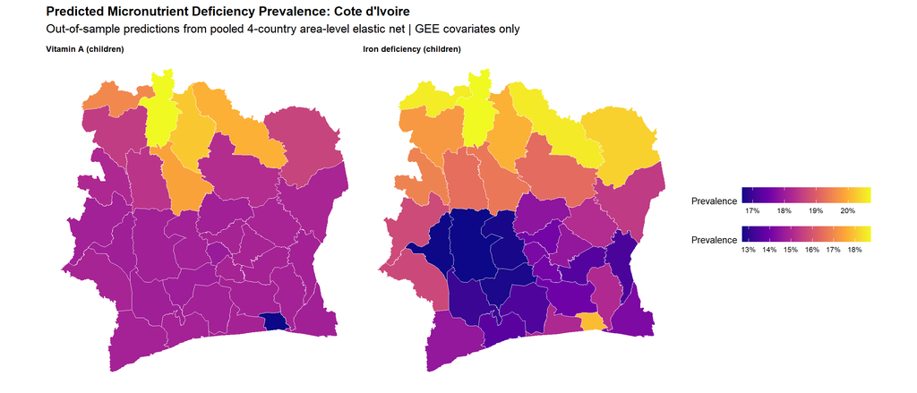

## 14.4 Admin-1 prevalence maps

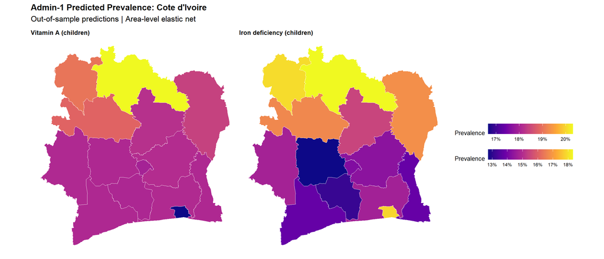

```r
if (n_oos > 0 && !is.null(civ_poly_a1)) {
  a1_panels <- list()

  for (oc_name in names(oos_civ)) {
    a1 <- oos_civ[[oc_name]]$admin1_preds
    if (is.null(a1) || nrow(a1) == 0) next

    prev_range <- max(a1$pred_prev, na.rm = TRUE) - min(a1$pred_prev, na.rm = TRUE)
    if (prev_range < 0.005) next

    map_data <- civ_poly_a1 |> left_join(a1, by = "Admin1")
    p <- ggplot(map_data) +
      geom_sf(aes(fill = pred_prev), colour = "white", linewidth = 0.3) +
      scale_fill_viridis_c(name = "Prevalence",
                            labels = scales::percent_format(accuracy = 1),
                            option = "plasma", na.value = "grey85") +
      labs(title = outcome_labels[oc_name]) +
      theme_void(base_size = 10) +
      theme(plot.title = element_text(size = 10, face = "bold"),
            legend.position = "bottom", legend.key.width = unit(1, "cm"))
    a1_panels[[oc_name]] <- p
  }

  if (length(a1_panels) > 0) {
    p_a1 <- Reduce(`+`, a1_panels) +
      plot_layout(ncol = min(length(a1_panels), 4), guides = "collect") +
      plot_annotation(
        title = "Admin-1 Predicted Prevalence: Cote d'Ivoire",
        subtitle = "Out-of-sample predictions | Area-level elastic net",
        theme = theme(plot.title = element_text(size = 14, face = "bold"))
      )
    print(p_a1)
  }
}
```

## 14.5 Conformal prediction interval width maps

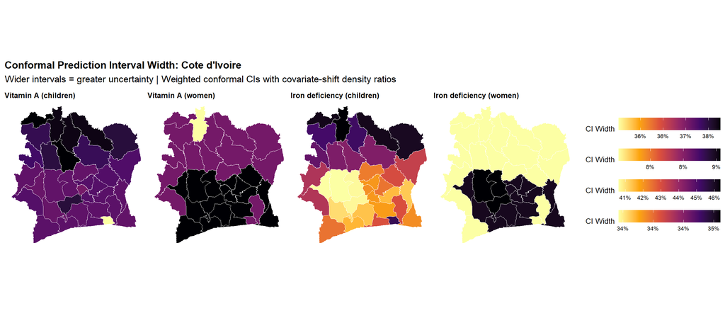

```r
if (n_oos > 0 && !is.null(civ_poly_a2)) {
  ci_panels <- list()

  for (oc_name in names(oos_civ)) {
    a2 <- oos_civ[[oc_name]]$admin2_preds
    if (is.null(a2) || nrow(a2) == 0) next
    if (!"ci_lo" %in% colnames(a2) || all(is.na(a2$ci_lo))) next

    a2 <- a2 |> mutate(ci_width = ci_hi - ci_lo)
    map_data <- civ_poly_a2 |> left_join(a2, by = "Admin2")

    p <- ggplot(map_data) +
      geom_sf(aes(fill = ci_width), colour = "white", linewidth = 0.15) +
      scale_fill_viridis_c(name = "CI Width",
                            labels = scales::percent_format(accuracy = 1),
                            option = "inferno", direction = -1,
                            na.value = "grey85") +
      labs(title = outcome_labels[oc_name]) +
      theme_void(base_size = 10) +
      theme(plot.title = element_text(size = 10, face = "bold"),
            legend.position = "bottom", legend.key.width = unit(1, "cm"))
    ci_panels[[oc_name]] <- p
  }

  if (length(ci_panels) > 0) {
    p_ci <- Reduce(`+`, ci_panels) +
      plot_layout(ncol = min(length(ci_panels), 4), guides = "collect") +
      plot_annotation(
        title = "Conformal Prediction Interval Width: Cote d'Ivoire",
        subtitle = "Wider intervals = greater uncertainty | Weighted conformal CIs with covariate-shift density ratios",
        theme = theme(plot.title = element_text(size = 14, face = "bold"))
      )
    print(p_ci)
  } else {
    cat("No conformal CIs available for CIV predictions.\n")
  }
}
```

## 14.6 Admin-1 forest plot

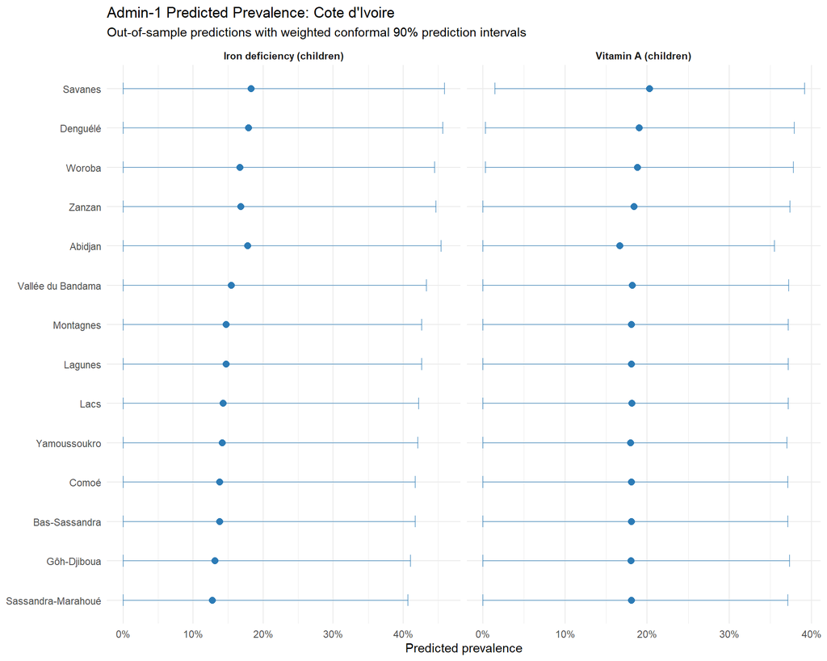

```r
if (n_oos > 0) {
  forest_rows <- list()
  for (oc_name in names(oos_civ)) {
    a1 <- oos_civ[[oc_name]]$admin1_preds
    if (!is.null(a1) && nrow(a1) > 0) {
      a1$outcome_label <- outcome_labels[oc_name]
      forest_rows[[oc_name]] <- a1
    }
  }

  if (length(forest_rows) > 0) {
    forest_df <- dplyr::bind_rows(forest_rows) |>
      dplyr::filter(!is.na(pred_prev))

    # Only plot outcomes with meaningful variation
    varied <- forest_df |>
      dplyr::group_by(outcome_label) |>
      dplyr::summarise(rng = max(pred_prev) - min(pred_prev), .groups = "drop") |>
      dplyr::filter(rng > 0.005)

    forest_plot_df <- forest_df |>
      dplyr::filter(outcome_label %in% varied$outcome_label)

    if (nrow(forest_plot_df) > 0) {
      has_ci <- "ci_lo" %in% colnames(forest_plot_df) &&
                any(!is.na(forest_plot_df$ci_lo))

      p <- ggplot(forest_plot_df,
             aes(x = pred_prev, y = reorder(Admin1, pred_prev)))

      if (has_ci) {
        p <- p + geom_errorbarh(aes(xmin = ci_lo, xmax = ci_hi),
                                height = 0.3, colour = "#2c7bb6", linewidth = 0.5,
                                alpha = 0.6)
      }
      p <- p +
        geom_point(colour = "#2c7bb6", size = 2.5) +
        scale_x_continuous(labels = percent_format(accuracy = 1)) +
        facet_wrap(~ outcome_label, scales = "free_x", ncol = 2) +
        labs(x = "Predicted prevalence", y = NULL,
             title = "Admin-1 Predicted Prevalence: Cote d'Ivoire",
             subtitle = if (has_ci)
               "Out-of-sample predictions with weighted conformal 90% prediction intervals"
             else
               "Out-of-sample pooled elastic net predictions") +
        theme_minimal(base_size = 11) +
        theme(strip.text = element_text(face = "bold"))
      print(p)
    }
  }
}
```